# Getting started with wrMisc

Wolfgang Raffelsberger

2023-07-25

## Introduction

This package contains a collection of various (low-level) tools which may be of general interest. These functions were accumulated over a number of years of data-wrangling when treating high-throughput data from biomedical applications. Besides, these functions are further used/integrated in more specialized functions dedicated to specific applications in the packages wrProteo, wrGraph or wrTopDownFrag. All these packages are available on [CRAN](https://cran.r-project.org/).

If you are not familiar with [R](https://www.r-project.org/) you may find many introductory documents on the official R-site in [contributed documents](https://cran.r-project.org/other-docs.html) or under [Documentation/Manuals](https://cran.r-project.org/manuals.html). Of course, numerous other documents/sites with tutorials and courses exist, too.

### Dependencies and Compilation

One of the aims was to write a package easy to install, with low system requirements and few obligatory dependencies.  
All code is written in pure R and does not need any special compilers. The number of obligatory dependencies was kept to a minumum.

Most of additional packages used in some of the functions were declared as ‘suggested’ (ie not obligatory), to allow installation of *wrMisc* even if some these additional packages can’t be installed/compiled by the user’s instance. When a feature/function of one of the ‘suggested’ packages is about to be used, its presence/installation will be checked and, only if found as missing, the user will be prompted a message inviting to install specific package(s) before using these specific functions. This helps to avoid not being able installing this package at all if some dependencies may fail to get installed themselves.

### Installation And Loading

To get started, we need to install (if not yet installed) and load the package “wrMisc” available from [CRAN](https://cran.r-project.org/).

```r
## If not already installed, you'll have to install the package first.
## This is the basic installation commande in R
install.packages("wrMisc")
```

Since the functions illustrated in this vignette require a number of the *suggested* packages, let’s check if they are installed and add them (via a small function), if not yet installed.

```r
packages <- c("knitr", "rmarkdown", "BiocManager", "kableExtra", "boot", "data.tree", "data.table",
  "fdrtool", "RColorBrewer", "Rcpp", "wrMisc", "wrGraph", "wrProteo")
checkInstallPkg <- function(pkg) {       # install function
  if(!requireNamespace(pkg, quietly=TRUE)) install.packages(pkg) }

## install if not yet present
sapply(packages, checkInstallPkg)
```

Finally, this package also uses the Bioconductor package [limma](https://bioconductor.org/packages/release/bioc/html/limma.html) which has to be installed differently (see also help on [Bioconductor](https://bioconductor.org)):

```r
## Installation of limma
BiocManager::install("limma")
```

This vignette is also accessible from R command-line or on CRAN at wrMisc:

```r
## Now you can open this vignette out of R:
vignette("wrMiscVignette1", package="wrMisc")
```

Before using the functions of this package, we actually need to load the package first (best on a fresh R-session):

```r
library("wrMisc")
library("knitr")

## This is 'wrMisc' version number :
packageVersion("wrMisc")
```

```
## [1] '1.12.0.2'
```

## Speed Optimized Functions In The Package wrMisc

In high-throughput experiments in biology (like transcriptomics, proteomics etc…) many different features get measured a number if times (different samples like patients or evolution of a disease). The resulting data typically contain many (independent) rows (eg >1000 different genes or proteins who’s abundance was measured) and much fewer columns that may get further organized in groups of replicates. As R is a versatile language, multiple options exist for assessing the global characteristics of such data, some are more efficient on a computational point of view. In order to allow fast treatment of very large data-sets some tools have been re-designed for optimal performance.

### Assessing Basic Information About Variability (for matrix)

Many measurement techniques applied in high throughput manner suffer from precision. This means, the same measurements taken twice in a row (ie repeated on the same subject) will very likely not give an identical result. For this reason it is common practice to make replicate measurements to i) estimate mean (ie representative) values and ii) asses the factors contributing to the variablity observed. Briefly, technical replicates represent the case where multiple read-outs of the very same sample are generated and the resulting variability is associated to technical issues during the process of taking measures. Biological replicates represent independant samples and reflect therefore the varibility a given parameter may have in a certain population of individuals. With the tools presented here, both technical and biological replicates can be dealt with. In several cases the interpretation of the resulting numbers should consider the experimental setup, though.

Let’s make a simple matrix as toy data:

```r
grp1 <- rep(LETTERS[1:3], c(3,4,3))
sampNa1 <- paste0(grp1, c(1:3,1:4,1:3))
set.seed(2016); dat1 <- matrix(round(c(runif(50000) +rep(1:1000,50)),3),
  ncol=10, dimnames=list(NULL,sampNa1))
dim(dat1)
```

```
## [1] 5000   10
```

```r
head(dat1)
```

```
##         A1    A2    A3    B1    B2    B3    B4    C1    C2    C3
## [1,] 1.180 1.640 1.199 1.118 1.425 1.745 1.253 1.554 1.303 1.856
## [2,] 2.143 2.237 2.730 2.693 2.603 2.293 2.542 2.452 2.148 2.776
## [3,] 3.842 3.155 3.191 3.520 3.686 3.408 3.409 3.871 3.345 3.588
## [4,] 4.134 4.394 4.982 4.320 4.380 4.888 4.965 4.462 4.250 4.647
## [5,] 5.478 5.472 5.488 5.570 5.626 5.765 5.551 5.016 5.659 5.139
## [6,] 6.121 6.294 6.718 6.890 6.999 6.316 6.542 6.119 6.763 6.487
```

Now lets estimate the standard deviation *(sd)* for every row:

```r
head(rowSds(dat1))
```

```
## [1] 0.2583693 0.2426026 0.2477899 0.3089102 0.2307722 0.3124493
```

```r
system.time(sd1 <- rowSds(dat1))
```

```
##    user  system elapsed
##       0       0       0
```

```r
system.time(sd2 <- apply(dat1, 1, sd))
```

```
##    user  system elapsed
##    0.14    0.03    0.17
```

On most systems the equivalent calculation using *apply()* will run much slower compared to `rowSds`.

Note, there is a minor issue with rounding :

```r
table(round(sd1, 13)==round(sd2, 13))
```

```
##
## FALSE  TRUE
##     1  4999
```

Similarly we can easily calculate the CV (coefficient of variation, ie sd / mean, see also [CV](https://en.wikipedia.org/wiki/Coefficient_of_variation)) for every row using `rowCVs` :

```r
system.time(cv1 <- rowCVs(dat1))
```

```
##    user  system elapsed
##       0       0       0
```

```r
system.time(cv2 <- apply(dat1, 1, sd) / rowMeans(dat1))
```

```
##    user  system elapsed
##    0.10    0.00    0.11
```

```r
# typically the calculation using rowCVs is much faster
head(cv1)
```

```
## [1] 0.18101959 0.09855083 0.07076678 0.06800894 0.04213940 0.04788568
```

```r
# results from the 'conventional' way
head(cv2)
```

```
## [1] 0.18101959 0.09855083 0.07076678 0.06800894 0.04213940 0.04788568
```

Note, these calculations will be very efficient as long as the number of rows is much higher (>>) than the number of columns.

### Data Organized In (Sub-)Groups As Sets Of Columns

Now, let’s assume our data is contains 3 initial samples measured as several replicates (already defined in *grp1*). Similarly, we can also calculate the sd or CV for each line while splitting into groups of replicates (functions `rowGrpMeans`, `rowGrpSds` and `rowGrpCV`):

```r
# we already defined the grouping :
grp1
```

```
##  [1] "A" "A" "A" "B" "B" "B" "B" "C" "C" "C"
```

```r
## the mean for each group and row
system.time(mean1Gr <- rowGrpMeans(dat1, grp1))
```

```
##    user  system elapsed
##       0       0       0
```

```r
## Now the sd for each row and group
system.time(sd1Gr <- rowGrpSds(dat1, grp1))
```

```
##    user  system elapsed
##       0       0       0
```

```r
# will give us a matrix with the sd for each group & line
head(sd1Gr)
```

```
##                A          B         C
## [1,] 0.260269732 0.27074758 0.2768917
## [2,] 0.315291928 0.17144557 0.3140531
## [3,] 0.386666523 0.13115989 0.2632534
## [4,] 0.434443706 0.33521970 0.1986530
## [5,] 0.008082904 0.09672297 0.3413156
## [6,] 0.307168249 0.31475851 0.3230934
```

```r
# Let's check the results of the first line :
sd1Gr[1,] == c(sd(dat1[1,1:3]), sd(dat1[1,4:7]), sd(dat1[1,8:10]))
```

```
##    A    B    C
## TRUE TRUE TRUE
```

```r
# The CV :
system.time(cv1Gr <- rowGrpCV(dat1, grp1))
```

```
##    user  system elapsed
##    0.01    0.00    0.01
```

```r
head(cv1Gr)
```

```
##                A          B          C
## [1,] 0.194279471 0.19545033 0.17625186
## [2,] 0.133034569 0.06769147 0.12773308
## [3,] 0.113859400 0.03741279 0.07309886
## [4,] 0.096471585 0.07227288 0.04461104
## [5,] 0.001475162 0.01718603 0.06474939
## [6,] 0.048163108 0.04707197 0.05004286
```

#### Counting Number Of NAs Per Row And Group Of Columns

Some data, like with quantitative proteomics measures, may contain an elevated number of *NAs* (see also the package wrProteo for further options for dealing with such data). Furthermore, many other packages on CRAN and Bioconductor cover this topic, see also the [missing data task-view](https://CRAN.R-project.org/view=MissingData) on CRAN. Similar as above there is an easy way to count the number of *NAs* to get an overview how NAs are distributed.

Let’s assume we have measures from 3 groups/samples with 4 replicates each :

```r
mat2 <- c(22.2, 22.5, 22.2, 22.2, 21.5, 22.0, 22.1, 21.7, 21.5, 22, 22.2, 22.7,
   NA, NA, NA, NA, NA, NA, NA, 21.2,   NA, NA, NA, NA,
   NA, 22.6, 23.2, 23.2,  22.4, 22.8, 22.8, NA,  23.3, 23.2, NA, 23.7,
   NA, 23.0, 23.1, 23.0,  23.2, 23.2, NA, 23.3,  NA, NA, 23.3, 23.8)
mat2 <- matrix(mat2, ncol=12, byrow=TRUE)
## The definition of the groups (ie replicates)
gr4 <- gl(3, 4, labels=LETTERS[1:3])
```

Now we can easily count the number of NAs per row and set of replicates.

```r
rowGrpNA(mat2,gr4)
```

```
##      A B C
## [1,] 0 0 0
## [2,] 4 3 4
## [3,] 1 1 1
## [4,] 1 1 2
```

### Fast NA-omit For Very Large Objects

The function *na.omit()* from the package *stats* also keeps a trace of all omitted instances. This can be penalizing in terms of memory usage when handling very large vectors with a high content of NAs (eg >10000 NAs). If you don’t need to document precisely which elements got eliminated, the function `naOmit()` may offer smoother functioning for very large objects.

```r
aA <- c(11:13,NA,10,NA)

str(naOmit(aA))
```

```
##  num [1:4] 11 12 13 10
```

```r
# the 'classical' na.omit also stores which elements were NA
str(na.omit(aA))
```

```
##  num [1:4] 11 12 13 10
##  - attr(*, "na.action")= 'omit' int [1:2] 4 6
```

### Minimum Distance/Difference Between Values

If you need to find the closest neighbour(s) of a numeric vector, the function `minDiff()` will tell you the distance (“dif”,“ppm” or “ratio”) and index (“best”) of the closest neighbour. In case of multiple shortest distances the index if the first one is reported, and the column “nbest” will display a value of >1.

```r
set.seed(2017); aa <- 10 *c(0.1 +round(runif(20),2), 0.53, 0.53)
head(aa)
```

```
## [1] 10.2  6.4  5.7  3.9  8.7  8.7
```

```r
minDiff(aa,ppm=FALSE)
```

```
##       index value  dif   rat ncur nbest best
##  [1,]     1  10.2 -0.2 0.981    1     1   19
##  [2,]     2   6.4  0.4 1.070    1     1   15
##  [3,]     3   5.7  0.3 0.950    2     1   15
##  [4,]     4   3.9  0.2 1.050    1     1   10
##  [5,]     5   8.7  0.5 1.060    2     1   18
##  [6,]     6   8.7  0.5 1.060    2     1   18
##  [7,]     7   1.4  0.1 1.080    1     1   13
##  [8,]     8   5.3  0.3 1.060    4     1   17
##  [9,]     9   5.7  0.3 0.950    2     1   15
## [10,]    10   3.7 -0.2 0.949    1     1    4
## [11,]    11   7.7 -0.5 0.939    1     1   18
## [12,]    12   1.0 -0.3 0.769    1     1   13
## [13,]    13   1.3 -0.1 0.929    1     1    7
## [14,]    14   5.3  0.3 1.060    4     1   17
## [15,]    15   6.0  0.3 1.050    1     2    9
## [16,]    16   4.9 -0.1 0.980    1     1   17
## [17,]    17   5.0  0.1 1.020    1     1   16
## [18,]    18   8.2  0.5 1.060    1     1   11
## [19,]    19  10.4  0.2 1.020    1     1    1
## [20,]    20   9.3  0.6 1.070    1     2    6
## [21,]    21   5.3  0.3 1.060    4     1   17
## [22,]    22   5.3  0.3 1.060    4     1   17
```

When you look at the first line, the value of 10.2 has one single closest value which is 10.4, which is located in line number 19 (the column ‘best’ gives the index of the best). Line number 19 points back to line number 1. You can see, that some elements (like 5.7) occure multiple times (line no 3 and 9), multiple occurences are counted in the column *ncur*. This is why column *nbest* for line 15 (*value* =6.0) indicates that it appears twice as closest value *nbest*.

## Working With Lists (And Lists Of Lists)

### Partial unlist

When input from different places gets collected and combined into a list, this may give a collection of different types of data. The function `partUnlist()` will to preserve multi-column elements as they are (and just bring down one level):

```r
bb <- list(fa=gl(2,2), ve=31:33, L2=matrix(21:28,ncol=2), li=list(li1=11:14,li2=data.frame(41:44)))
partUnlist(bb)
```

```
## $fa
## [1] 1 1 2 2
## Levels: 1 2
##
## $ve
## [1] 31 32 33
##
## $L2
##      [,1] [,2]
## [1,]   21   25
## [2,]   22   26
## [3,]   23   27
## [4,]   24   28
##
## $li1
## [1] 11 12 13 14
##
## $li2
##   X41.44
## 1     41
## 2     42
## 3     43
## 4     44
```

```r
partUnlist(lapply(bb,.asDF2))
```

```
## partUnlist : Input is not list of lists, nothing to do
```

```
## $fa
##   as.character(z)
## 1               1
## 2               1
## 3               2
## 4               2
##
## $ve
##    z
## 1 31
## 2 32
## 3 33
##
## $L2
##   V1 V2
## 1 21 25
## 2 22 26
## 3 23 27
## 4 24 28
##
## $li
##   li1 X41.44
## 1  11     41
## 2  12     42
## 3  13     43
## 4  14     44
```

This won’t be possible using *unlist()*.

```r
head(unlist(bb, recursive=FALSE))
```

```
## $fa1
## [1] 1
##
## $fa2
## [1] 1
##
## $fa3
## [1] 2
##
## $fa4
## [1] 2
##
## $ve1
## [1] 31
##
## $ve2
## [1] 32
```

To uniform such data to obtain a list with one column only for each list-element, the function `asSepList()` provides help :

```r
bb <- list(fa=gl(2,2), ve=31:33, L2=matrix(21:28,ncol=2), li=list(li1=11:14,li2=data.frame(41:44)))
asSepList(bb)
```

```
## $fa
## [1] 1 1 2 2
## Levels: 1 2
##
## $L2_1
## [1] 21 22 23 24
##
## $L2_2
## [1] 25 26 27 28
##
## $li1
## [1] 11 12 13 14
##
## $li2
## [1] 41 42 43 44
```

### Appending/Combining Lists

Separate lists may be combined using the *append()* command, which also allows treating simple vectors.

```r
li1 <- list(a=1, b=2, c=3)
li2 <- list(A=11, b=2, C=13)
append(li1, li2)
```

```
## $a
## [1] 1
##
## $b
## [1] 2
##
## $c
## [1] 3
##
## $A
## [1] 11
##
## $b
## [1] 2
##
## $C
## [1] 13
```

However, this way there is no checking if some of the list-elements are present in both lists and thus will appear twice. The function `appendNR()` allows to checking if some list-elements will appear twice, and thus avoid such duplicate entries.

```r
appendNR(li1, li2)
```

```
## appendNR :  adding 2 new names/elements (1 already present)
```

```
## $a
## [1] 1
##
## $b
## [1] 2
##
## $c
## [1] 3
##
## $A
## [1] 11
##
## $C
## [1] 13
```

### rbind On Lists

When a matrix (or data.frame) gets split into a list, like in the example using *by()*, as a reverse-function such lists can get joined using `lrbind()` in an *rbind*-like fashion.

```r
dat2 <- matrix(11:34, ncol=3, dimnames=list(letters[1:8], colnames=LETTERS[1:3]))
lst2 <- by(dat2, rep(1:3,c(3,2,3)), as.matrix)
lst2
```

```
## INDICES: 1
##    A  B  C
## a 11 19 27
## b 12 20 28
## c 13 21 29
## ------------------------------------------------------------
## INDICES: 2
##    A  B  C
## d 14 22 30
## e 15 23 31
## ------------------------------------------------------------
## INDICES: 3
##    A  B  C
## f 16 24 32
## g 17 25 33
## h 18 26 34
```

```r
# join list-elements (back) into single matrix
lrbind(lst2)
```

```
##    A  B  C
## a 11 19 27
## b 12 20 28
## c 13 21 29
## d 14 22 30
## e 15 23 31
## f 16 24 32
## g 17 25 33
## h 18 26 34
```

### Merge Multiple Matrices From List

When combining different datasets the function `mergeMatrixList()` allows merging multiple matrices (or data.frames) into a single matrix. Two types of mode of operation are available : i) Returning only the common/shared elements (as defined by the rownames), this is default *mode=‘intersect’* ; alternatively one may ii) fuse/merge all matrices together without any loss of data (using *mode=‘union’*, additional _NA_s may appear when a given rowname is absent in one of the input matrices).

Furthermore, one may specifically select which columns should be used for fusing using the argument *useColumn*.

```r
mat1 <- matrix(11:18, ncol=2, dimnames=list(letters[3:6],LETTERS[1:2]))
mat2 <- matrix(21:28, ncol=2, dimnames=list(letters[2:5],LETTERS[3:4]))
mat3 <- matrix(31:38, ncol=2, dimnames=list(letters[c(1,3:4,3)],LETTERS[4:5]))
#
mergeMatrixList(list(mat1, mat2), useColumn="all")
```

```
##    A  B  C  D
## c 11 15 22 26
## d 12 16 23 27
## e 13 17 24 28
```

```r
# with custom names for the individual matrices
mergeMatrixList(list(m1=mat1, m2=mat2, mat3), mode="union", useColumn=2)
```

```
##   m1.B m2.D list_3.E
## a   NA   NA       35
## b   NA   25       NA
## c   15   26       38
## d   16   27       37
## e   17   28       NA
## f   18   NA       NA
```

Similarly, separate entries may be merged using `mergeMatrices()` :

```r
mergeMatrices(mat1, mat2)
```

```
##    A
## c 11 22
## d 12 23
## e 13 24
```

```r
mergeMatrices(mat1, mat2, mat3, mode="union", useColumn=2)
```

```
##   mat1.B mat2.D mat3.E
## a     NA     NA     35
## b     NA     25     NA
## c     15     26     38
## d     16     27     37
## e     17     28     NA
## f     18     NA     NA
```

```r
## custom names for matrix-origin
mergeMatrices(m1=mat1, m2=mat2, mat3, mode="union", useColumn=2)
```

```
##   m1.B m2.D mat3.E
## a   NA   NA     35
## b   NA   25     NA
## c   15   26     38
## d   16   27     37
## e   17   28     NA
## f   18   NA     NA
```

```r
## flexible/custom selection of columns
mergeMatrices(m1=mat1, m2=mat2, mat3, mode="union", useColumn=list(1,1:2,2))
```

```
##   m1.A m2.C m2.D mat3.E
## a   NA   NA   NA     35
## b   NA   21   25     NA
## c   11   22   26     38
## d   12   23   27     37
## e   13   24   28     NA
## f   14   NA   NA     NA
```

### Fuse Content Of List-Elements With Redundant (Duplicated) Names

When list-elements have the same name, their content (of named numeric or character vectors) may get fused using `fuseCommonListElem()` according to the names of the list-elements :

```r
val1 <- 10 +1:26
names(val1) <- letters
(lst1 <- list(c=val1[3:6], a=val1[1:3], b=val1[2:3] ,a=val1[12], c=val1[13]))
```

```
## $c
##  c  d  e  f
## 13 14 15 16
##
## $a
##  a  b  c
## 11 12 13
##
## $b
##  b  c
## 12 13
##
## $a
##  l
## 22
##
## $c
##  m
## 23
```

```r
## here the names 'a' and 'c' appear twice :
names(lst1)
```

```
## [1] "c" "a" "b" "a" "c"
```

```r
## now, let's fuse all 'a' and 'c'
fuseCommonListElem(lst1)
```

```
## $c
##  c  d  e  f  m
## 13 14 15 16 23
##
## $a
##  a  b  c  l
## 11 12 13 22
##
## $b
##  b  c
## 12 13
```

### Filtering Lines And/Or Columns For All List-Elements Of Same Size

In a number of cases the information in various list-elements is somehow related. Eg, in S3-objects produced by [limma](https://bioconductor.org/packages/release/bioc/html/limma.html), or data produced using wrProteo several instances of matrix or data.frame refer to data that are related. Some matrixes may conatain abundance data (or weights, etc) while another matrix or data.frame may contain the annotation information related to each line of the abundance data. So if one wants to filter the data, ie remove some lines, this should be done in the same way with all related list-elements. This way one may maintain a conventient 1:1 matching of lines.

The function `filterLiColDeList()` searches if other list-elements have suitable dimensions and will then run the same filtering as in the ‘target’ list-element. In consequence this can be used with the output of wrProteo to remove simultaneously the same lines and/or columns.

```r
lst1 <- list(m1=matrix(11:18, ncol=2), m2=matrix(21:30, ncol=2), indR=31:34,
  m3=matrix(c(21:23,NA,25:27,NA), ncol=2))
filterLiColDeList(lst1, useLines=2:3)
```

```
## filterLiColDeList : successfully filtered 'm1' and 'm3' from 4 to 2 lines
```

```
## $m1
##      [,1] [,2]
## [1,]   12   16
## [2,]   13   17
##
## $m2
##      [,1] [,2]
## [1,]   21   26
## [2,]   22   27
## [3,]   23   28
## [4,]   24   29
## [5,]   25   30
##
## $indR
## [1] 31 32 33 34
##
## $m3
##      [,1] [,2]
## [1,]   22   26
## [2,]   23   27
```

```r
filterLiColDeList(lst1, useLines="allNA", ref=3)
```

```
## filterLiColDeList : It appears lst[[ref]] is not matrix (or data.frame) ! Trying to reformat ..
```

```
## filterLiColDeList : 'useLines' seems empty, nothing to do ...
```

```
## $m1
##      [,1] [,2]
## [1,]   11   15
## [2,]   12   16
## [3,]   13   17
## [4,]   14   18
##
## $m2
##      [,1] [,2]
## [1,]   21   26
## [2,]   22   27
## [3,]   23   28
## [4,]   24   29
## [5,]   25   30
##
## $indR
##      [,1]
## [1,]   31
## [2,]   32
## [3,]   33
## [4,]   34
##
## $m3
##      [,1] [,2]
## [1,]   21   25
## [2,]   22   26
## [3,]   23   27
## [4,]   NA   NA
```

### Replacements In List

The function `listBatchReplace()` works similar to *sub()* and allows to search & replace exact matches to a character string along all elements of a list.

```r
(lst1 <- list(aa=1:4, bb=c("abc","efg","abhh","effge"), cc=c("abdc","efg","efgh")))
```

```
## $aa
## [1] 1 2 3 4
##
## $bb
## [1] "abc"   "efg"   "abhh"  "effge"
##
## $cc
## [1] "abdc" "efg"  "efgh"
```

```r
listBatchReplace(lst1, search="efg", repl="EFG", silent=FALSE)
```

```
## $aa
## [1] "1" "2" "3" "4"
##
## $bb
## [1] "abc"   "EFG"   "abhh"  "effge"
##
## $cc
## [1] "abdc" "EFG"  "efgh"
```

### Organize Values Into list and Sort By Names

Named numeric or character vectors can be organized into lists using `listGroupsByNames()`, based on their names (only the part before any extensions starting with a point gets considered). Of course, other separators may be defined using the argument *sep*.

```r
ser1 <- 1:7; names(ser1) <- c("AA","BB","AA.1","CC","AA.b","BB.e","A")

listGroupsByNames(ser1)
```

```
## $AA
##   AA AA.1 AA.b
##    1    3    5
##
## $BB
##   BB BB.e
##    2    6
##
## $CC
## CC
##  4
##
## $A
## A
## 7
```

If no names are present, the content of the vector itself will be used as name :

```r
listGroupsByNames((1:10)/5)
```

```
## listGroupsByNames :  no names found in 'x' !!
```

```
## $`0`
##   0   0   0   0
## 0.2 0.4 0.6 0.8
##
## $`1`
##   1   1   1   1   1
## 1.0 1.2 1.4 1.6 1.8
##
## $`2`
## 2
## 2
```

### Batch-filter List-Elements

In the view of object-oriented programming several methods produce results integrated into lists or S3-objects (eg [limma](https://bioconductor.org/packages/release/bioc/html/limma.html)). The function `filterList()` aims facilitating the filtering of all elements of lists or S3-objects. List-elements with inappropriate number of lines will be ignored.

```r
set.seed(2020); dat1 <- round(runif(80),2)
list1 <- list(m1=matrix(dat1[1:40], ncol=8), m2=matrix(dat1[41:80], ncol=8), other=letters[1:8])
rownames(list1$m1) <- rownames(list1$m2) <- paste0("line",1:5)
# Note: the list-element list1$other has a length different to that of filt. Thus, it won't get filtered.
filterList(list1, list1$m1[,1] >0.4)       # filter according to 1st column of $m1 ...
```

```
## $m1
##       [,1] [,2] [,3] [,4] [,5] [,6] [,7] [,8]
## line1 0.65 0.07 0.76 0.54 0.20 0.17 0.96 0.37
## line3 0.62 0.39 0.83 0.65 0.82 0.75 0.96 0.93
## line4 0.48 0.00 0.42 0.55 0.94 0.45 0.95 0.52
##
## $m2
##       [,1] [,2] [,3] [,4] [,5] [,6] [,7] [,8]
## line1 0.99 0.57 0.58 0.00 0.21 0.61 0.61 0.30
## line3 0.86 0.70 0.90 0.22 0.23 0.58 0.39 0.06
## line4 0.88 0.80 0.52 0.54 0.42 0.65 0.47 0.67
##
## $other
## [1] "a" "b" "c" "d" "e" "f" "g" "h"
```

```r
filterList(list1, list1$m1 >0.4)
```

```
## $m1
##       [,1] [,2] [,3] [,4] [,5] [,6] [,7] [,8]
## line1 0.65 0.07 0.76 0.54 0.20 0.17 0.96 0.37
## line3 0.62 0.39 0.83 0.65 0.82 0.75 0.96 0.93
## line4 0.48 0.00 0.42 0.55 0.94 0.45 0.95 0.52
## line5 0.14 0.62 0.41 0.27 0.88 0.56 0.00 0.22
##
## $m2
##       [,1] [,2] [,3] [,4] [,5] [,6] [,7] [,8]
## line1 0.99 0.57 0.58 0.00 0.21 0.61 0.61 0.30
## line3 0.86 0.70 0.90 0.22 0.23 0.58 0.39 0.06
## line4 0.88 0.80 0.52 0.54 0.42 0.65 0.47 0.67
## line5 0.62 0.17 0.83 0.49 0.86 0.17 0.53 0.72
##
## $other
## [1] "a" "b" "c" "d" "e" "f" "g" "h"
```

### Transform Columns Of Matrix To List Of Vectors

At some occasions it may be useful separate columns of a matrix into separate vectors inside a list. This can be done using `matr2list()`:

```r
(mat1 <- matrix(1:12, ncol=3, dimnames=list(letters[1:4],LETTERS[1:3])))
```

```
##   A B  C
## a 1 5  9
## b 2 6 10
## c 3 7 11
## d 4 8 12
```

```r
str(matr2list(mat1))
```

```
## List of 3
##  $ A: Named num [1:4] 1 2 3 4
##   ..- attr(*, "names")= chr [1:4] "A.a" "A.b" "A.c" "A.d"
##  $ B: Named num [1:4] 5 6 7 8
##   ..- attr(*, "names")= chr [1:4] "B.a" "B.b" "B.c" "B.d"
##  $ C: Named num [1:4] 9 10 11 12
##   ..- attr(*, "names")= chr [1:4] "C.a" "C.b" "C.c" "C.d"
```

## Working With Arrays

Let’s get stared with a little toy-array:

```r
(arr1 <- array(c(6:4,4:24), dim=c(4,3,2), dimnames=list(c(LETTERS[1:4]),
  paste("col",1:3,sep=""),c("ch1","ch2"))))
```

```
## , , ch1
##
##   col1 col2 col3
## A    6    5    9
## B    5    6   10
## C    4    7   11
## D    4    8   12
##
## , , ch2
##
##   col1 col2 col3
## A   13   17   21
## B   14   18   22
## C   15   19   23
## D   16   20   24
```

### CV (Coefficient Of Variance) With Arrays

Now we can obtain the CV (coefficient of variance) by splitting along 3rd dimesion (ie this is equivalent to an *apply* along the 3rd dimension) using `arrayCV()`:

```r
arrayCV(arr1)
```

```
##         ch1       ch2
## A 0.3122499 0.2352941
## B 0.3779645 0.2222222
## C 0.4788934 0.2105263
## D 0.5000000 0.2000000
```

```r
# this is equivalent to
cbind(rowCVs(arr1[,,1]), rowCVs(arr1[,,2]))
```

```
##        [,1]      [,2]
## A 0.3122499 0.2352941
## B 0.3779645 0.2222222
## C 0.4788934 0.2105263
## D 0.5000000 0.2000000
```

Similarly we can split along any other dimension, eg the 2nd dimension :

```r
arrayCV(arr1, byDim=2)
```

```
##        col1      col2      col3
## A 0.5210260 0.7713892 0.5656854
## B 0.6698906 0.7071068 0.5303301
## C 0.8187552 0.6527140 0.4991342
## D 0.8485281 0.6060915 0.4714045
```

### Slice 3-dim Array In List Of Matrixes (Or Arrays)

This procedure is similar to (re-)organizing an initial array into clusters, here we split along a user-defined factor/vector. If a clustering-algorithm produces the cluster assignments, this function can be used to organize the input data accordingly using `cutArrayInCluLike()`.

```r
cutArrayInCluLike(arr1, cluOrg=c(2,1,2,1))
```

```
## $`2`
## , , ch1
##
##   col1 col2 col3
## A    6    5    9
## C    4    7   11
##
## , , ch2
##
##   col1 col2 col3
## A   13   17   21
## C   15   19   23
##
##
## $`1`
## , , ch1
##
##   col1 col2 col3
## B    5    6   10
## D    4    8   12
##
## , , ch2
##
##   col1 col2 col3
## B   14   18   22
## D   16   20   24
```

Let’s cut by filtering along the 3rd dimension for all lines where column ‘col2’ is >7, and then display only the content of columns ‘col1’ and ‘col2’ (using `filt3dimArr()`):

```r
filt3dimArr(arr1, displCrit=c("col1","col2"), filtCrit="col2", filtVal=7, filtTy=">")
```

```
## [[1]]
## col1 col2
##    4    8
##
## [[2]]
##   col1 col2
## A   13   17
## B   14   18
## C   15   19
## D   16   20
```

## Working With Redundant Data

$_Semantics_$ : Please note, that there are two ways of interpreting the term ‘**unique**’ :

- In regular understanding one describes this way an event which occurs only once, and thus does not occur/happen anywhere else.
- The command `unique()` will eliminate redundant entries to obtain a shorter ‘unique’ output vector, ie in the resultant vector all values/content (values) occur only once. However, from the result of *unique()* you cannot tell any more which ones were not unique initially !

In some applications (eg proteomics) initial identifiers (IDs) may occur multiple times in the data and we frequently need to identify events/values that occur only once, as the first meaning of ‘*unique*’. This package provides (additional) functions to easily distinguish values occurring just once (ie *unique*) from those occurring multiple times. Furthermore, there are functions to rename/remove/combine replicated elements, eg `correctToUnique()` or `nonAmbiguousNum()`, so that no elements or lines of data get lost.

### Identify What Is Repeated (and Where Repeated Do Occur)

```r
## some text toy data
tr <- c("li0","n",NA,NA, rep(c("li2","li3"),2), rep("n",4))
```

The function *table()* (from the package *base*) is very useful get some insights when working with smaller objects, but may be slow to handle very large objects. As mentioned, *unique()* will make everything unique, and afterwards you won’t know any more who was unique in the first place ! The function `duplicated()` (also from package base) helps us getting the information who is repeated.

```r
table(tr)
```

```
## tr
## li0 li2 li3   n
##   1   2   2   5
```

```r
unique(tr)
```

```
## [1] "li0" "n"   NA    "li2" "li3"
```

```r
duplicated(tr, fromLast=FALSE)
```

```
##  [1] FALSE FALSE FALSE  TRUE FALSE FALSE  TRUE  TRUE  TRUE  TRUE  TRUE  TRUE
```

```r
aa <- c(11:16,NA,14:12,NA,14)
names(aa) <- letters[1:length(aa)]
aa
```

```
##  a  b  c  d  e  f  g  h  i  j  k  l
## 11 12 13 14 15 16 NA 14 13 12 NA 14
```

`findRepeated()` (from this package) will return the position/index (and content/value) of repeated elements. However, the output in form of a list is not very convenient to the human reader.

```r
findRepeated(aa)
```

```
## $`12`
## [1]  2 10
##
## $`13`
## [1] 3 9
##
## $`14`
## [1]  4  8 12
```

`firstOfRepeated()` tells the index of the first instance of repeated elements, which elements you need to make the vector ‘unique’, and which elements get stripped off when making unique. Please note, that *NA* (no matter if they occure once or more times) are automatically in the part suggested to be removed.

```r
firstOfRepeated(aa)
```

```
## $indRepeated
## 12 13 14
##  2  3  4
##
## $indUniq
## a b c d e f
## 1 2 3 4 5 6
##
## $indRedund
##  g  h  i  j  k  l
##  7  8  9 10 11 12
```

```r
aa[firstOfRepeated(aa)$indUniq]          # only unique with their names
```

```
##  a  b  c  d  e  f
## 11 12 13 14 15 16
```

```r
unique(aa)                               # unique() does not return any names !
```

```
## [1] 11 12 13 14 15 16 NA
```

### Correct Vector To Unique (While Maintaining The Original Vector Length)

If necessary, a counter can be added to non-unique entries, thus no individual values get eliminated and the length and order of the resultant object maintains the same using `correctToUnique()`.

This is of importance when assigning rownames to a data.frame : Assigning redundant values/text as rownames of a data.frame will result in an error !

```r
correctToUnique(aa)
```

```
##      a      b      c      d      e      f      g      h      i      j      k
##   "11" "12_1" "13_1" "14_1"   "15"   "16" "NA_1" "14_2" "13_2" "12_2" "NA_2"
##      l
## "14_3"
```

```r
correctToUnique(aa, sep=".", NAenum=FALSE)       # keep NAs (ie without transforming to character)
```

```
##      a      b      c      d      e      f      g      h      i      j      k
##   "11" "12.1" "13.1" "14.1"   "15"   "16"     NA "14.2" "13.2" "12.2"     NA
##      l
## "14.3"
```

You see from the last example above, that this function has an argument for controlling enumerating elements.

### Mark Any Duplicated (ie Ambiguous) Elements by Changing Their Names (and Separate from Unqiue)

First, the truly unique values are reported and then the first occurance of repeated elements is given, *NA* instances get ignored. This can be done using `nonAmbiguousNum()` which maintains the length of the initial character vector.

```r
unique(aa)                                    # names are lost
```

```
## [1] 11 12 13 14 15 16 NA
```

```r
nonAmbiguousNum(aa)
```

```
##     a     e     f amb_b amb_c
##    11    15    16    12    13
```

```r
nonAmbiguousNum(aa, uniq=FALSE, asLi=TRUE)    # separate in list unique and repeated
```

```
## $unique
##  a  e  f
## 11 15 16
##
## $ambig
## amb_b amb_c
##    12    13
```

### Compare Multiple Vectors And Sort By Number Of Common/Repeated Values/Words

The main aim of the function `sortByNRepeated()` is allowing to compare multiple vectors for common values/words and providing an output sorted by number of repeats.

Suppose 3 persons are asked which cities they wanted to visit. Then we would like to make a counting of the most frequently cited cities. Here we consider individual choices as equally ranked. By default intra-repeats are eliminated.

```r
cities <- c("Bangkok","London","Paris", "Singapore","New York City", "Istambul","Delhi","Rome","Dubai")
sortByNRepeated(x=cities[c(1:4)], y=cities[c(2:3,5:8)])
```

```
## $`1`
## [1] "Bangkok"       "Delhi"         "Istambul"      "New York City"
## [5] "Rome"          "Singapore"
##
## $`2`
## [1] "London" "Paris"
```

```r
## or (unlimited) multiple inputs via list
choices1 <- list(Mary=cities[c(1:4)], Olivia=cities[c(2:3,5:8)], Paul=cities[c(5:3,9,5)])    # Note : Paul cited NYC twice !
table(unlist(choices1))
```

```
##
##       Bangkok         Delhi         Dubai      Istambul        London
##             1             1             1             1             2
## New York City         Paris          Rome     Singapore
##             3             3             1             2
```

```r
sortByNRepeated(choices1)
```

```
## $`1`
## [1] "Bangkok"  "Delhi"    "Dubai"    "Istambul" "Rome"
##
## $`2`
## [1] "London"        "New York City" "Singapore"
##
## $`3`
## [1] "Paris"
```

```r
sortByNRepeated(choices1, filterIntraRep=FALSE)  # without correcting multiple citation of NYC by Paul
```

```
## $`1`
## [1] "Bangkok"  "Delhi"    "Dubai"    "Istambul" "Rome"
##
## $`2`
## [1] "London"    "Singapore"
##
## $`3`
## [1] "New York City" "Paris"
```

### Combine Multiple Matrixes Where Some Column-Names Are The Same

Here, it is supposed that you want to join 2 or more matrixes describing different properties of the same collection of individuals (as rows). Common column-names are interpreted that their respective information should be combined (either as average or as sum). This can be done using `cbindNR()` :

```r
## First we'll make soe toy data :
(ma1 <- matrix(1:6, ncol=3, dimnames=list(1:2,LETTERS[3:1])))
```

```
##   C B A
## 1 1 3 5
## 2 2 4 6
```

```r
(ma2 <- matrix(11:16, ncol=3, dimnames=list(1:2,LETTERS[3:5])))
```

```
##    C  D  E
## 1 11 13 15
## 2 12 14 16
```

```r
## now we can join 2 or more matrixes
cbindNR(ma1, ma2, summarizeAs="mean")       # average of both columns 'C'
```

```
## cbindNR :  treating 5 different (types of) columns : C B A D E
```

```
## cbindNR :   sorting columns of output
```

```
##   A B C  D  E
## 1 5 3 6 13 15
## 2 6 4 7 14 16
```

### Filter Matrix To Keep Only First Of Repeated Lines

This ressembles to the functioning of *unique()*, but applies to a user-specified column of the matrix.

```r
(mat1 <- matrix(c(1:6, rep(1:3,1:3)), ncol=2, dimnames=list(letters[1:6],LETTERS[1:2])))
```

```
##   A B
## a 1 1
## b 2 2
## c 3 2
## d 4 3
## e 5 3
## f 6 3
```

The function `firstLineOfDat()` allows to access/extract the first line of repeated instances.

```r
firstLineOfDat(mat1, refCol=2)
```

```
##   A B
## a 1 1
## b 2 2
## d 4 3
```

This function was rather designed for dealing with character input, it allows concatenating all columns and to remove redundant.

```r
mat2 <- matrix(c("e","n","a","n","z","z","n","z","z","b",
  "","n","c","n","","","n","","","z"), ncol=2)
firstOfRepLines(mat2, out="conc")
```

```
## [1] "e"  "nn" "ac" "z"  "bz"
```

```r
# or as index :
firstOfRepLines(mat2)
```

```
## [1]  1  2  3  5 10
```

### Filter To Unique Column-Content Of Matrix, Add Counter And Concatenated Information

```r
(df1 <- data.frame(cbind(xA=letters[1:5], xB=c("h","h","f","e","f"), xC=LETTERS[1:5])))
```

```
##   xA xB xC
## 1  a  h  A
## 2  b  h  B
## 3  c  f  C
## 4  d  e  D
## 5  e  f  E
```

The function `nonredDataFrame()` offers to include a counter of redundant instances encountered (for 1st column specified) :

```r
nonredDataFrame(df1, useCol=c("xB","xC"))
```

[output not shown]

```r
# without counter or concatenating
df1[which(!duplicated(df1[,2])),]
```

```
##   xA xB xC
## 1  a  h  A
## 3  c  f  C
## 4  d  e  D
```

```r
# or
df1[firstOfRepLines(df1,useCol=2),]
```

```
##   xA xB xC
## 1  a  h  A
## 3  c  f  C
## 4  d  e  D
```

### Get First Of Repeated By Column

```r
mat2 <- cbind(no=as.character(1:20), seq=sample(LETTERS[1:15], 20, repl=TRUE),
  ty=sample(c("full","Nter","inter"),20,repl=TRUE), ambig=rep(NA,20), seqNa=1:20)
(mat2uniq <- get1stOfRepeatedByCol(mat2, sortBy="seq", sortSupl="ty"))
```

```
##       no   seq ty      ambig  seqNa
##  [1,] "6"  "M" "Nter"  NA     "6"
##  [2,] "11" "C" "inter" NA     "11"
##  [3,] "12" "N" "Nter"  NA     "12"
##  [4,] "17" "J" "full"  NA     "17"
##  [5,] "18" "A" "full"  NA     "18"
##  [6,] "19" "O" "Nter"  NA     "19"
##  [7,] "7"  "B" "Nter"  "TRUE" "_7"
##  [8,] "10" "D" "full"  "TRUE" "_10"
##  [9,] "8"  "E" "full"  "TRUE" "_8"
## [10,] "9"  "F" "full"  "TRUE" "_9"
## [11,] "2"  "G" "full"  "TRUE" "_2"
## [12,] "3"  "H" "Nter"  "TRUE" "_3"
```

```r
# the values from column 'seq' are indeed unique
table(mat2uniq[,"seq"])
```

```
##
## A B C D E F G H J M N O
## 1 1 1 1 1 1 1 1 1 1 1 1
```

```r
# This will return all first repeated (may be >1) but without furter sorting
#  along column 'ty' neither marking in comumn 'ambig').
mat2[which(duplicated(mat2[,2],fromLast=FALSE)),]
```

```
##      no   seq ty     ambig seqNa
## [1,] "5"  "H" "Nter" NA    "5"
## [2,] "8"  "E" "full" NA    "8"
## [3,] "9"  "F" "full" NA    "9"
## [4,] "13" "G" "Nter" NA    "13"
## [5,] "14" "D" "full" NA    "14"
## [6,] "15" "D" "full" NA    "15"
## [7,] "16" "B" "Nter" NA    "16"
## [8,] "20" "F" "full" NA    "20"
```

### Transform (ambigous) Matrix To Non-ambiguous Matrix (In Respect To Given Column)

```r
nonAmbiguousMat(mat1,by=2)
```

```
##       A B
## 1     1 1
## amb_3 3 2
## amb_6 6 3
```

Here another example, ambiguous will be marked by an ’_’ :

```r
set.seed(2017); mat3 <- matrix(c(1:100,round(rnorm(200),2)), ncol=3,
  dimnames=list(1:100,LETTERS[1:3]));
head(mat3U <- nonAmbiguousMat(mat3, by="B", na="_", uniqO=FALSE), n=15)
```

```
##      A     B     C
## 81  81 -2.59 -0.14
## 93  93 -2.02 -0.03
## 7    7 -1.96  0.52
## 4    4 -1.76  0.84
## _74 74 -1.65  0.30
## 55  55 -1.59  1.25
## 52  52 -1.58 -0.24
## 15  15 -1.43 -0.60
## 98  98 -1.34  0.41
## 63  63 -1.33  0.26
## 19  19 -1.13  0.70
## 41  41 -1.06 -0.56
## _56 56 -1.03 -1.07
## 94  94 -0.98 -0.02
## 95  95 -0.97  0.08
```

```r
head(get1stOfRepeatedByCol(mat3, sortB="B", sortS="B"))
```

```
##   A     B     C
## 1 1  1.43  0.02
## 2 2 -0.08  1.38
## 3 3  0.74 -0.07
## 4 4 -1.76  0.84
## 5 5 -0.07 -0.97
## 6 6  0.45 -1.97
```

### Combine Replicates From List To Matrix

```r
lst2 <- list(aa_1x=matrix(1:12, nrow=4, byrow=TRUE), ab_2x=matrix(24:13, nrow=4, byrow=TRUE))
combineReplFromListToMatr(lst2)
```

```
## $a
##        1
##  [1,]  1
##  [2,]  4
##  [3,]  7
##  [4,] 10
##  [5,]  2
##  [6,]  5
##  [7,]  8
##  [8,] 11
##  [9,]  3
## [10,]  6
## [11,]  9
## [12,] 12
##
## $b
##        2
##  [1,] 24
##  [2,] 21
##  [3,] 18
##  [4,] 15
##  [5,] 23
##  [6,] 20
##  [7,] 17
##  [8,] 14
##  [9,] 22
## [10,] 19
## [11,] 16
## [12,] 13
```

### Non-redundant Lines Of Matrix

```r
mat4 <- matrix(rep(c(1,1:3,3,1),2), ncol=2, dimnames=list(letters[1:6],LETTERS[1:2]))
nonRedundLines(mat4)
```

```
##   A B
## a 1 1
## c 2 2
## d 3 3
## f 1 1
```

### Filter For Unique Elements /2

```r
# input: c and dd are repeated  :
filtSizeUniq(list(A="a", B=c("b","bb","c"), D=c("dd","d","ddd","c")), filtUn=TRUE, minSi=NULL)
```

```
## filtSizeUniq : 2 out of 8 peptides redundant
```

```
## $A
##   A
## "a"
##
## $B
##  B.1  B.2
##  "b" "bb"
##
## $D
##   D.1   D.2   D.3
##  "dd"   "d" "ddd"
```

```r
# here a,b,c and dd are repeated  :
filtSizeUniq(list(A="a", B=c("b","bb","c"), D=c("dd","d","ddd","c")), ref=c(letters[c(1:26,1:3)],
  "dd","dd","bb","ddd"), filtUn=TRUE, minSi=NULL)
```

```
## filtSizeUniq : 8 out of 8 peptides redundant
```

```
## $A
## character(0)
##
## $B
## character(0)
##
## $D
## character(0)
```

### Make Non-redundant Matrix

```r
t3 <- data.frame(ref=rep(11:15,3), tx=letters[1:15],
  matrix(round(runif(30,-3,2),1), nc=2), stringsAsFactors=FALSE)

# First we split the data.frame in list
by(t3,t3[,1],function(x) x)
```

```
## t3[, 1]: 11
##    ref tx  X1   X2
## 1   11  a 0.4 -1.1
## 6   11  f 0.6  1.0
## 11  11  k 0.1  1.2
## ------------------------------------------------------------
## t3[, 1]: 12
##    ref tx   X1   X2
## 2   12  b  2.0 -0.4
## 7   12  g -0.3  1.8
## 12  12  l -1.4  0.3
## ------------------------------------------------------------
## t3[, 1]: 13
##    ref tx  X1   X2
## 3   13  c 0.8 -1.6
## 8   13  h 0.8 -2.4
## 13  13  m 0.9  1.8
## ------------------------------------------------------------
## t3[, 1]: 14
##    ref tx   X1   X2
## 4   14  d  1.7  0.7
## 9   14  i -1.6 -2.6
## 14  14  n  1.4 -1.1
## ------------------------------------------------------------
## t3[, 1]: 15
##    ref tx   X1   X2
## 5   15  e -0.9  0.4
## 10  15  j -1.7  0.0
## 15  15  o -1.2 -1.8
```

```r
t(sapply(by(t3,t3[,1],function(x) x), summarizeCols, me="maxAbsOfRef"))
```

```
##    [,1] [,2] [,3] [,4]
## 11 11   "a"  0.1  1.2
## 12 12   "b"  -0.3 1.8
## 13 13   "c"  0.8  -2.4
## 14 14   "d"  -1.6 -2.6
## 15 15   "e"  -1.2 -1.8
```

```r
(xt3 <- makeNRedMatr(t3, summ="mean", iniID="ref"))
```

```
## makeNRedMatr : Common summarization method 'mean', run as batch
```

```
## makeNRedMatr : Summarize redundant based on col 'ref'  using method(s) : 'mean', 'mean', 'mean' and 'mean' yielding 4 cols
```

```
##    ID ref tx         X1         X2 nRedLi
## 11 11  11  a  0.3666667  0.3666667      3
## 12 12  12  b  0.1000000  0.5666667      3
## 13 13  13  c  0.8333333 -0.7333333      3
## 14 14  14  d  0.5000000 -1.0000000      3
## 15 15  15  e -1.2666667 -0.4666667      3
```

```r
(xt3 <- makeNRedMatr(t3, summ=unlist(list(X1="maxAbsOfRef")), iniID="ref"))
```

```
## makeNRedMatr : Summarize redundant based on col 'ref'  using method(s) : 'maxAbsOfRef' and col 'X1' yielding 4 cols
```

```
##    ref tx  X1   X2   nRedLi
## 11 11  "a" 0.6  1    3
## 12 12  "b" 2    -0.4 3
## 13 13  "c" 0.9  1.8  3
## 14 14  "d" 1.7  0.7  3
## 15 15  "e" -1.7 0    3
```

### Combine/Reduce Redundant Lines Based On Specified Column

```r
matr <- matrix(c(letters[1:6],"h","h","f","e",LETTERS[1:5]), ncol=3,
  dimnames=list(letters[11:15],c("xA","xB","xC")))
combineRedBasedOnCol(matr, colN="xB")
```

```
##   xA    xB  xC
## 2 "a,d" "f" "A,D"
## 3 "b,c" "h" "B,C"
## 1 "e"   "e" "E"
```

```r
combineRedBasedOnCol(rbind(matr[1,],matr), colN="xB")
```

```
##   xA    xB  xC
## 2 "a,d" "f" "A,D"
## 3 "b,c" "h" "B,C"
## 1 "e"   "e" "E"
```

### Convert Matrix (eg With Redundant) Row-Names To data.frame

```r
x <- 1
dat1 <- matrix(1:10, ncol=2)
rownames(dat1) <- letters[c(1:3,2,5)]
## as.data.frame(dat1)  ...  would result in an error
convMatr2df(dat1)
```

```
##     ID X1 X2
## a    a  1  6
## b_1  b  2  7
## c    c  3  8
## b_2  b  4  9
## e    e  5 10
```

```r
convMatr2df(data.frame(a=as.character((1:3)/2), b=LETTERS[1:3], c=1:3))
```

```
##     a b c
## 1 0.5 A 1
## 2 1.0 B 2
## 3 1.5 C 3
```

```r
tmp <- data.frame(a=as.character((1:3)/2), b=LETTERS[1:3], c=1:3, stringsAsFactors=FALSE)
convMatr2df(tmp)
```

```
##     a b c
## 1 0.5 A 1
## 2 1.0 B 2
## 3 1.5 C 3
```

```r
tmp <- data.frame(a=as.character((1:3)/2), b=1:3, stringsAsFactors=FALSE)
convMatr2df(tmp)
```

```
##     a b
## 1 0.5 1
## 2 1.0 2
## 3 1.5 3
```

### Find And Combine Points Located Very Close In X/Y Space

```r
set.seed(2013)
datT2 <- matrix(round(rnorm(200)+3,1), ncol=2, dimnames=list(paste("li",1:100,sep=""),
  letters[23:24]))
# (mimick) some short and longer names for each line
inf2 <- cbind(sh=paste(rep(letters[1:4],each=26), rep(letters,4),1:(26*4),sep=""),
  lo=paste(rep(LETTERS[1:4],each=26), rep(LETTERS,4), 1:(26*4), ",",
  rep(letters[sample.int(26)],4), rep(letters[sample.int(26)],4), sep=""))[1:100,]
## We'll use this to test :
head(datT2, n=10)
```

```
##        w   x
## li1  2.9 3.7
## li2  3.8 3.3
## li3  2.3 3.3
## li4  4.4 3.1
## li5  4.5 1.8
## li6  0.4 2.4
## li7  3.7 3.3
## li8  3.3 4.0
## li9  5.0 4.1
## li10 1.6 1.1
```

```r
## let's assign to each pair of x & y values a 'cluster' (column _clu_, the column _combInf_ tells us which lines/indexes are in this cluster)
head(combineOverlapInfo(datT2, disThr=0.03), n=10)
```

```
##        w   x       combInf clu isComb
## li1  2.9 3.7 1+16+22+47+91   1   TRUE
## li2  3.8 3.3     2+7+48+54   2   TRUE
## li3  2.3 3.3       3+66+92   3   TRUE
## li4  4.4 3.1             4  52  FALSE
## li5  4.5 1.8             5  53  FALSE
## li6  0.4 2.4             6  54  FALSE
## li7  3.7 3.3     2+7+48+54   2   TRUE
## li8  3.3 4.0         8+100   4   TRUE
## li9  5.0 4.1             9  55  FALSE
## li10 1.6 1.1            10  56  FALSE
```

```r
## it is also possible to rather display names (eg gene or protein-names) instead of index values
head(combineOverlapInfo(datT2, suplI=inf2[,2], disThr=0.03), n=10)
```

```
##        w   x                 combInf clu isComb
## li1  2.9 3.7 AA1+AP16+AV22+BU47+DM91   1   TRUE
## li2  3.8 3.3       AB2+AG7+BV48+CB54   2   TRUE
## li3  2.3 3.3           AC3+CN66+DN92   3   TRUE
## li4  4.4 3.1                  AD4,ww  52  FALSE
## li5  4.5 1.8                  AE5,aj  53  FALSE
## li6  0.4 2.4                  AF6,nl  54  FALSE
## li7  3.7 3.3       AB2+AG7+BV48+CB54   2   TRUE
## li8  3.3 4.0               AH8+DV100   4   TRUE
## li9  5.0 4.1                  AI9,ic  55  FALSE
## li10 1.6 1.1                 AJ10,ee  56  FALSE
```

### Bin And Summarize Values According To Their Names

```r
dat <- 11:19
names(dat) <- letters[c(6:3,2:4,8,3)]
## Here the names are not unique.
## Thus, the values can be binned by their (non-unique) names and a representative values calculated.

## Let's make a 'datUniq' with the mean of each group of values :
datUniq <- round(tapply(dat, names(dat), mean),1)
## now we propagate the mean values to the full vector
getValuesByUnique(dat, datUniq)
```

```
##    f    e    d    c    b    c    d    h    c
## 11.0 12.0 15.0 16.3 15.0 16.3 15.0 18.0 16.3
```

```r
cbind(ini=dat,firstOfRep=getValuesByUnique(dat, datUniq),
  indexUniq=getValuesByUnique(dat, datUniq, asIn=TRUE))
```

```
##   ini firstOfRep indexUniq
## f  11       11.0         5
## e  12       12.0         4
## d  13       15.0         3
## c  14       16.3         2
## b  15       15.0         1
## c  16       16.3         2
## d  17       15.0         3
## h  18       18.0         6
## c  19       16.3         2
```

### Regrouping Simultaneaously by Two Factors

For example, if you wish to create group-labels considering the eye- and hair-color of a small group students (supposed a sort of controlled vocabulary was used), the function `combineByEitherFactor()` will help. So basically, this is an empiric segmentation-approach for two categorical variables. Please note, that with large data-sets and very disperse data this approach will not provide great results. In the example below we’ll attempt to ‘cluster’ according to columns *nn* and *qq*, the resultant cluster number can be found in column *grp*.

```r
nn <- rep(c("a","e","b","c","d","g","f"),c(3,1,2,2,1,2,1))
qq <- rep(c("m","n","p","o","q"),c(2,1,1,4,4))
nq <- cbind(nn,qq)[c(4,2,9,11,6,10,7,3,5,1,12,8),]
## Here we consider 2 columns 'nn' and 'qq' whe trying to regroup common values
##  (eg value 'a' from column 'nn' and value 'o' from 'qq')
combineByEitherFactor(nq, 1, 2, nBy=FALSE)
```

```
##    nn  qq  grp
## m2 "a" "m" "1"
## q2 "f" "q" "3"
## q1 "d" "q" "3"
## o2 "b" "o" "2"
## p  "e" "p" "4"
## o4 "c" "o" "2"
## q4 "g" "q" "3"
## n  "a" "n" "1"
## m1 "a" "m" "1"
## q3 "g" "q" "3"
## o1 "b" "o" "2"
## o3 "c" "o" "2"
```

```r
## the same, but including n by group/cluster
combineByEitherFactor(nq, 1, 2, nBy=TRUE)
```

```
##    nn  qq  grp nGrp
## m2 "a" "m" "1" "3"
## q2 "f" "q" "3" "4"
## q1 "d" "q" "3" "4"
## o2 "b" "o" "2" "4"
## p  "e" "p" "4" "1"
## o4 "c" "o" "2" "4"
## q4 "g" "q" "3" "4"
## n  "a" "n" "1" "3"
## m1 "a" "m" "1" "3"
## q3 "g" "q" "3" "4"
## o1 "b" "o" "2" "4"
## o3 "c" "o" "2" "4"
```

```r
## Not running further iterations works faster, but you may not reach 'convergence' immediately
combineByEitherFactor(nq,1, 2, nBy=FALSE)
```

```
##    nn  qq  grp
## m2 "a" "m" "1"
## q2 "f" "q" "3"
## q1 "d" "q" "3"
## o2 "b" "o" "2"
## p  "e" "p" "4"
## o4 "c" "o" "2"
## q4 "g" "q" "3"
## n  "a" "n" "1"
## m1 "a" "m" "1"
## q3 "g" "q" "3"
## o1 "b" "o" "2"
## o3 "c" "o" "2"
```

```r
##  another example
mm <- rep(c("a","b","c","d","e"), c(3,4,2,3,1))
pp <- rep(c("m","n","o","p","q"), c(2,2,2,2,5))
combineByEitherFactor(cbind(mm,pp), 1, 2, con=FALSE, nBy=TRUE)
```

```
## combineByEitherFactor :  did not reach convergence at 2nd pass
```

```
##    mm  pp  grp nGrp
## m1 "a" "m" "1" "4"
## m2 "a" "m" "1" "4"
## n1 "a" "n" "1" "4"
## n2 "b" "n" "1" "4"
## o1 "b" "o" "2" "4"
## o2 "b" "o" "2" "4"
## p1 "b" "p" "2" "4"
## p2 "c" "p" "2" "4"
## q1 "c" "q" "3" "5"
## q2 "d" "q" "3" "5"
## q3 "d" "q" "3" "5"
## q4 "d" "q" "3" "5"
## q5 "e" "q" "3" "5"
```

### Batch Replacing Of Values Or Character-Strings

The function `multiCharReplace()` facilitates multiple replacements in a vector, matrix or data.frame.

```r
# replace character content
x1 <- c("ab","bc","cd","efg","ghj")
multiCharReplace(x1, cbind(old=c("bc","efg"), new=c("BBCC","EF")))
```

```
## [1] "ab"   "BBCC" "cd"   "EF"   "ghj"
```

```r
# works also on matrix and/or to replace numeric content :
x3 <- matrix(11:16, ncol=2)
multiCharReplace(x3, cbind(12:13,112:113))
```

```
##      [,1] [,2]
## [1,]   11   14
## [2,]  112   15
## [3,]  113   16
```

Sometimes data get imported using different encoding for what should be interpreted as *FALSE* and *TRUE* :

```r
# replace and return logical vactor
x2 <- c("High","n/a","High","High","Low")
multiCharReplace(x2,cbind(old=c("n/a","Low","High"), new=c(NA,FALSE,TRUE)), convTo="logical")
```

```
## [1]  TRUE    NA  TRUE  TRUE FALSE
```

### Multi-to-multi Matching Of (Concatenated) Terms

The function allows to split (if necessary, using *strsplit()*) two vectors and compare each isolated tag (eg identifyer) from the 1st vector/object against each isolated tag from the second vector/object. This runs like a loop of one to many comparisons. The basic output is a list with indexes of which element of the 1st vector/object has matches in the 2nd vector/object. Since this is not convenient to the human reader, tabular output can be created, too.

```r
aa <- c("m","k","j; aa","m; aa; bb; o","n; dd","aa","cc")
bb <- c("aa","dd","aa; bb; q","p; cc")
## result as list of indexes
(bOnA <- multiMatch(aa, bb, method="asIndex"))   # match bb on aa
```

```
## $`1`
## named integer(0)
##
## $`2`
## named integer(0)
##
## $`3`
## aa aa
##  1  3
##
## $`4`
## aa aa bb
##  1  3  3
##
## $`5`
## dd
##  2
##
## $`6`
## aa aa
##  1  3
##
## $`7`
## cc
##  4
```

```r
## more convenient to the human reader
(bOnA <- multiMatch(aa, bb))                     # match bb on aa
```

```
##              x x.Ind TagBest y.IndBest y.IndAll   y.Match        y.Adj
## 1            m     1    <NA>        NA     <NA>      <NA>         <NA>
## 2            k     2    <NA>        NA     <NA>      <NA>         <NA>
## 3        j; aa     3      aa         1     1; 3        aa        j; aa
## 4 m; aa; bb; o     4      aa         3  1; 3; 3 aa; bb; q m; aa; bb; o
## 5        n; dd     5      dd         2        2        dd        n; dd
## 6           aa     6      aa         1     1; 3        aa           aa
## 7           cc     7      cc         4        4     p; cc           cc
```

```r
(bOnA <- multiMatch(aa, bb, method="matchedL"))  # match bb on aa
```

```
## $`1`
## named integer(0)
##
## $`2`
## named integer(0)
##
## $`3`
## aa aa
##  1  3
##
## $`4`
## aa aa bb
##  1  3  3
##
## $`5`
## dd
##  2
##
## $`6`
## aa aa
##  1  3
##
## $`7`
## cc
##  4
```

### Comparing Global Patterns

In most programming languages it is fairly easy to compare *exact* content of character vectors or factors with unordered levels. However, sometimes - due to semantic issues - some people may call a color ‘purple’ while others call it ‘violet’. Thus, without using controled vocabulary the *exact* terms may vary.

Here, let’s address the case, where no dictionaries of controled vocabulary are available for substituting equivalent terms. Thus, we’ll compare 4 vectors of equal length and check if the words/letters used could be substituted to result in the first vector. Vectors *aa* and *ab* have the same global pattern, ie after repeating a word twice it moves to another word. Vectors *ac* and *ad* have different general patterns, either with alternating words or falling back to a word previsously used.

Based and extended on a post on stackoverflow https://stackoverflow.com/questions/71353218/extracting-flexible-general-patterns/ :

```r
aa <- letters[rep(c(3:1,4), each=2)]
ab <- letters[rep(c(5,8:6), each=2)]        # 'same general' pattern to aa
ac <- letters[c(1:2,1:3,3:4,4)]             # NOT 'same general' pattern to any other
ad <- letters[c(6:8,8:6,7:6)]               # NOT 'same general' pattern to any other
```

The basic pattern can be extracted combining match() and unique():

```r
## get global patterns
cbind(aa= match(aa, unique(aa)),
  ab= match(ab, unique(ab)),
  ac= match(ac, unique(ac)),
  ad= match(ad, unique(ad)) )
```

```
##      aa ab ac ad
## [1,]  1  1  1  1
## [2,]  1  1  2  2
## [3,]  2  2  1  3
## [4,]  2  2  2  3
## [5,]  3  3  3  2
## [6,]  3  3  3  1
## [7,]  4  4  4  2
## [8,]  4  4  4  1
```

Let’s make a data.frame with the annotation toy-data from above. Each line is supposed to represent a sample, and the columns show different aspects of annotation.

```r
bb <- data.frame(ind=1:length(aa), a=aa, b=ab, c=ac, d=ad)
```

Via the function `replicateStructure()` is it possible to compare annotation as different columns for equivalent global patterns.

By default, this function excludes all columns not designating any replicates, like the numbers in the first column ($ind). Also it will try to find the column with the median number of levels, when comparing to all other columns.

The output is a list with *$col* inidicating which column(s) may be used, *$lev* for the correpsonding global pattern, *$meth* for the method finally used and *$allCols* for documenting the global pattern in each column (whether it was selected or not).

```r
replicateStructure(bb)
```

```
## $col
## a
## 2
##
## $lev
## c c b b a a d d
## 1 1 2 2 3 3 4 4
##
## $meth
## [1] "single median col"
```

Besides, it is also possible to combine all columns if one considers they contribute complementary substructures of the overal annotation.

```r
replicateStructure(bb, method="combAll")
```

```
## $col
## a c d
## 2 4 5
##
## $lev
## c_a_f c_b_g b_a_h b_b_h a_c_g a_c_f d_d_g d_d_f
##     1     2     3     4     5     6     7     8
##
## $meth
## [1] "comb all col"
```

However, when combining multiple columns it may happen -like in the example above- that finally no more lines remain being considered as replicates.

This can also be found when one column describes the groups and another gives the order of the replicates therein. However, for calling a (standard) statistical test it may be necessary exclude these replicate-numbers to designate the groups of replicates.

To overcome the problem of loosing the understanding of replicate-structure when combining all factors, it is possible to look for non-orthogonal structures, ie to try excluding columns which (after combining) would suggest no replicates after combining all columns. See the example below :

```r
replicateStructure(bb, method="combNonOrth")
```

```
## $col
## a d
## 2 5
##
## $lev
## c_f c_g b_h b_h a_g a_f d_g d_f
##   1   2   3   3   4   5   6   7
##
## $meth
## [1] "combNonOrth col"
```

## Search For Similar (Numeric) Values

This section addresses values that are not truly *identical* but may differ only in the very last digit(s) and thus may be in a pragmatic view get considered and treated as ‘about the same’. The simplest approach would be to round values and then look for identical values. The functions presented here (like `checkSimValueInSer()`) offer this type of search in a convenient way.

```r
va1 <- c(4:7,7,7,7,7,8:10) +(1:11)/28600
checkSimValueInSer(va1)
```

```
##  [1] FALSE FALSE FALSE  TRUE  TRUE  TRUE  TRUE  TRUE FALSE FALSE FALSE
```

```r
cbind(va=va1, simil=checkSimValueInSer(va1))
```

```
##              va simil
##  [1,]  4.000035     0
##  [2,]  5.000070     0
##  [3,]  6.000105     0
##  [4,]  7.000140     1
##  [5,]  7.000175     1
##  [6,]  7.000210     1
##  [7,]  7.000245     1
##  [8,]  7.000280     1
##  [9,]  8.000315     0
## [10,]  9.000350     0
## [11,] 10.000385     0
```

### Find Similar Numeric Values Of Two Columns Of A Matrix

The search for similar values may be preformed as absolute distance or as ‘ppm’ (as it is eg usual in proteomics when comparing measured and theoretically expected mass).

```r
aA <- c(11:17); bB <- c(12.001,13.999); cC <- c(16.2,8,9,12.5,15.9,13.5,15.7,14.1,5)
(cloMa <- findCloseMatch(x=aA, y=cC, com="diff", lim=0.5, sor=FALSE))
```

```
## $x2
##  y4
## 0.5
##
## $x3
##   y4   y6
## -0.5  0.5
##
## $x4
##   y6   y8
## -0.5  0.1
##
## $x6
##   y1   y5   y7
##  0.2 -0.1 -0.3
```

The result of *findCloseMatch()* is a list organized by each ‘x’, telling all instances of ‘y’ found within the distance tolerance given by *lim*. Using `closeMatchMatrix()` the result obtained above, can be presented in a more convenient format for the human eye.

```r
# all matches (of 2d arg) to/within limit for each of 1st arg ('x'); 'y' ..to 2nd arg = cC
# first let's display only one single closest/best hit
(maAa <- closeMatchMatrix(cloMa, aA, cC, lim=TRUE))  #
```

```
##      id.aA aA id.cC   cC disToPred ppmToPred nByGrp isMin nBest
## [1,]     2 12     4 12.5      -0.5  -40000.0      1     1     1
## [2,]     3 13     4 12.5       0.5   40000.0      2     1     2
## [3,]     3 13     6 13.5      -0.5  -37037.0      2     1     2
## [4,]     4 14     8 14.1      -0.1   -7092.2      2     1     1
## [5,]     6 16     5 15.9       0.1    6289.3      3     1     1
```

```r
(maAa <- closeMatchMatrix(cloMa, aA, cC, lim=FALSE,origN=TRUE))  #
```

```
##      id.aA aA id.cC   cC disToPred ppmToPred nByGrp isMin nBest
## [1,]     2 12     4 12.5      -0.5  -40000.0      1     1     1
## [2,]     3 13     4 12.5       0.5   40000.0      2     1     2
## [3,]     3 13     6 13.5      -0.5  -37037.0      2     1     2
## [4,]     4 14     6 13.5       0.5   37037.0      2     0     0
## [5,]     4 14     8 14.1      -0.1   -7092.2      2     1     1
## [6,]     6 16     7 15.7       0.3   19108.0      3     0     0
## [7,]     6 16     5 15.9       0.1    6289.3      3     1     1
## [8,]     6 16     1 16.2      -0.2  -12346.0      3     0     0
```

```r
(maAa <- closeMatchMatrix(cloMa, cbind(valA=81:87, aA), cbind(valC=91:99, cC), colM=2,
  colP=2, lim=FALSE))
```

```
## closeMatchMatrix : Reset argument 'origNa' to FALSE since names of 'predMatr' and/or 'measMatr' result of formula and would be too long
```

```
##      id.pred valA aA id.meas valC   cC disToPred ppmToPred nByGrp isMin nBest
## [1,]       2   82 12       4   94 12.5      -0.5  -40000.0      1     1     1
## [2,]       3   83 13       4   94 12.5       0.5   40000.0      2     1     2
## [3,]       3   83 13       6   96 13.5      -0.5  -37037.0      2     1     2
## [4,]       4   84 14       6   96 13.5       0.5   37037.0      2     0     0
## [5,]       4   84 14       8   98 14.1      -0.1   -7092.2      2     1     1
## [6,]       6   86 16       7   97 15.7       0.3   19108.0      3     0     0
## [7,]       6   86 16       5   95 15.9       0.1    6289.3      3     1     1
## [8,]       6   86 16       1   91 16.2      -0.2  -12346.0      3     0     0
```

```r
(maAa <- closeMatchMatrix(cloMa, cbind(aA,valA=81:87), cC, lim=FALSE, deb=TRUE))  #
```

```
## closeMatchMatrix : .. xxidentToMatr2a
```

```
## closeMatchMatrix : .. xxidentToMatr2c
```

```
## closeMatchMatrix : Reset argument 'origNa' to FALSE since names of 'predMatr' and/or 'measMatr' result of formula and would be too long
```

```
## closeMatchMatrix : .. xxidentToMatr2d
```

```
## closeMatchMatrix : .. xxidentToMatr2e
```

```
## closeMatchMatrix : .. xxidentToMatr2f
```

```
##      id.pred aA valA id.meas measMatr disToPred ppmToPred nByGrp isMin nBest
## [1,]       2 12   82       4     12.5      -0.5  -40000.0      1     1     1
## [2,]       3 13   83       4     12.5       0.5   40000.0      2     1     2
## [3,]       3 13   83       6     13.5      -0.5  -37037.0      2     1     2
## [4,]       4 14   84       6     13.5       0.5   37037.0      2     0     0
## [5,]       4 14   84       8     14.1      -0.1   -7092.2      2     1     1
## [6,]       6 16   86       7     15.7       0.3   19108.0      3     0     0
## [7,]       6 16   86       5     15.9       0.1    6289.3      3     1     1
## [8,]       6 16   86       1     16.2      -0.2  -12346.0      3     0     0
```

```r
a2 <- aA; names(a2) <- letters[1:length(a2)];  c2 <- cC; names(c2) <- letters[10 +1:length(c2)]
(cloM2 <- findCloseMatch(x=a2, y=c2, com="diff", lim=0.5, sor=FALSE))
```

```
## $b
##   n
## 0.5
##
## $c
##    n    p
## -0.5  0.5
##
## $d
##    p    r
## -0.5  0.1
##
## $f
##    k    o    q
##  0.2 -0.1 -0.3
```

```r
(maA2 <- closeMatchMatrix(cloM2, predM=cbind(valA=81:87, a2),
  measM=cbind(valC=91:99, c2), colM=2, colP=2, lim=FALSE, asData=TRUE))
```

```
## closeMatchMatrix : Reset argument 'origNa' to FALSE since names of 'predMatr' and/or 'measMatr' result of formula and would be too long
```

```
##     id.pred valA a2 id.meas valC   c2 disToPred ppmToPred nByGrp isMin nBest
## b         b   82 12       n   94 12.5      -0.5  -40000.0      1     1     1
## c_1       c   83 13       n   94 12.5       0.5   40000.0      2     1     2
## c_2       c   83 13       p   96 13.5      -0.5  -37037.0      2     1     2
## d_1       d   84 14       p   96 13.5       0.5   37037.0      2     0     0
## d_2       d   84 14       r   98 14.1      -0.1   -7092.2      2     1     1
## f_1       f   86 16       q   97 15.7       0.3   19108.0      3     0     0
## f_2       f   86 16       o   95 15.9       0.1    6289.3      3     1     1
## f_3       f   86 16       k   91 16.2      -0.2  -12346.0      3     0     0
```

```r
(maA2 <- closeMatchMatrix(cloM2, cbind(id=names(a2), valA=81:87,a2), cbind(id=names(c2),
  valC=91:99,c2), colM=3, colP=3, lim=FALSE, deb=FALSE))
```

```
## closeMatchMatrix : Reset argument 'origNa' to FALSE since names of 'predMatr' and/or 'measMatr' result of formula and would be too long
```

```
##   id.pred valA a2   id.meas valC c2     disToPred             ppmToPred nByGrp
## b "b"     "82" "12" "n"     "94" "12.5" "-0.5"                "-40000"  "1"
## c "c"     "83" "13" "n"     "94" "12.5" "0.5"                 "40000"   "2"
## c "c"     "83" "13" "p"     "96" "13.5" "-0.5"                "-37037"  "2"
## d "d"     "84" "14" "p"     "96" "13.5" "0.5"                 "37037"   "2"
## d "d"     "84" "14" "r"     "98" "14.1" "-0.0999999999999996" "-7092.2" "2"
## f "f"     "86" "16" "q"     "97" "15.7" "0.300000000000001"   "19108"   "3"
## f "f"     "86" "16" "o"     "95" "15.9" "0.0999999999999996"  "6289.3"  "3"
## f "f"     "86" "16" "k"     "91" "16.2" "-0.199999999999999"  "-12346"  "3"
##   isMin nBest
## b "1"   "1"
## c "1"   "2"
## c "1"   "2"
## d "0"   "0"
## d "1"   "1"
## f "0"   "0"
## f "1"   "1"
## f "0"   "0"
```

### Find Similar Numeric Values From Two Vectors/Matrixes

For comparing two sets of data one may use `findSimilarFrom2sets()`.

```r
aA <- c(11:17); bB <- c(12.001,13.999); cC <- c(16.2,8,9,12.5,12.6,15.9,14.1)
aZ <-  matrix(c(aA,aA+20), ncol=2, dimnames=list(letters[1:length(aA)],c("aaA","aZ")))
cZ <-  matrix(c(cC,cC+20), ncol=2, dimnames=list(letters[1:length(cC)],c("ccC","cZ")))
findCloseMatch(cC, aA, com="diff", lim=0.5, sor=FALSE)
```

```
## $x1
##   y6
## -0.2
##
## $x4
##   y2   y3
## -0.5  0.5
##
## $x5
##  y3
## 0.4
##
## $x6
##  y6
## 0.1
##
## $x7
##   y4
## -0.1
```

```r
findSimilFrom2sets(aA, cC)
```

```
##      aA predMatr cC measMatr disToPred ppmToPred nByGrp isMin nBest
## [1,]  2       12  4     12.5      -0.5  -40000.0      1     1     1
## [2,]  3       13  4     12.5       0.5   40000.0      2     0     0
## [3,]  3       13  5     12.6       0.4   31746.0      2     1     1
## [4,]  4       14  7     14.1      -0.1   -7092.2      1     1     1
## [5,]  6       16  6     15.9       0.1    6289.3      2     1     1
## [6,]  6       16  1     16.2      -0.2  -12346.0      2     0     0
```

```r
findSimilFrom2sets(cC, aA)
```

```
##      cC predMatr aA measMatr disToPred ppmToPred nByGrp isMin nBest
## [1,]  1     16.2  6       16       0.2   12500.0      1     1     1
## [2,]  4     12.5  2       12       0.5   41667.0      2     1     2
## [3,]  4     12.5  3       13      -0.5  -38462.0      2     1     2
## [4,]  5     12.6  3       13      -0.4  -30769.0      1     1     1
## [5,]  6     15.9  6       16      -0.1   -6250.0      1     1     1
## [6,]  7     14.1  4       14       0.1    7142.9      1     1     1
```

```r
findSimilFrom2sets(aA, cC, best=FALSE)
```

```
##      aA predMatr cC measMatr disToPred ppmToPred nByGrp isMin nBest
## [1,]  2       12  4     12.5      -0.5  -40000.0      1     1     1
## [2,]  3       13  4     12.5       0.5   40000.0      2     0     0
## [3,]  3       13  5     12.6       0.4   31746.0      2     1     1
## [4,]  4       14  7     14.1      -0.1   -7092.2      1     1     1
## [5,]  6       16  6     15.9       0.1    6289.3      2     1     1
## [6,]  6       16  1     16.2      -0.2  -12346.0      2     0     0
```

```r
findSimilFrom2sets(aA, cC, comp="ppm", lim=5e4, deb=TRUE)
```

```
## findSimilFrom2sets : findCloseMatch : fCM1
```

```
## findSimilFrom2sets : findCloseMatch : fCM2
```

```
## findSimilFrom2sets : findCloseMatch : fCM3
```

```
## findSimilFrom2sets : xxfindSimilFrom2sets2
```

```
## findSimilFrom2sets : closeMatchMatrix : .. xxidentToMatr2a
```

```
## findSimilFrom2sets : closeMatchMatrix : .. xxidentToMatr2c
```

```
## findSimilFrom2sets : closeMatchMatrix : .. xxidentToMatr2d
```

```
## findSimilFrom2sets : closeMatchMatrix : .. xxidentToMatr2e
```

```
## findSimilFrom2sets : closeMatchMatrix : .. xxidentToMatr2f
```

```
##      aA predMatr cC measMatr disToPred ppmToPred nByGrp isMin nBest
## [1,]  2       12  4     12.5      -0.5  -40000.0      1     1     1
## [2,]  3       13  4     12.5       0.5   40000.0      2     0     0
## [3,]  3       13  5     12.6       0.4   31746.0      2     1     1
## [4,]  4       14  7     14.1      -0.1   -7092.2      1     1     1
## [5,]  6       16  6     15.9       0.1    6289.3      2     1     1
## [6,]  6       16  1     16.2      -0.2  -12346.0      2     0     0
## [7,]  7       17  1     16.2       0.8   49383.0      1     1     1
```

```r
findSimilFrom2sets(aA, cC, comp="ppm", lim=9e4, bestO=FALSE)
```

```
##       aA predMatr cC measMatr disToPred ppmToPred nByGrp isMin nBest
##  [1,]  2       12  4     12.5      -0.5  -40000.0      2     1     1
##  [2,]  2       12  5     12.6      -0.6  -47619.0      3     0     0
##  [3,]  3       13  4     12.5       0.5   40000.0      2     0     0
##  [4,]  3       13  5     12.6       0.4   31746.0      3     1     1
##  [5,]  3       13  7     14.1      -1.1  -78014.0      3     0     0
##  [6,]  4       14  7     14.1      -0.1   -7092.2      1     1     1
##  [7,]  5       15  7     14.1       0.9   63830.0      3     1     2
##  [8,]  5       15  6     15.9      -0.9  -56604.0      3     1     2
##  [9,]  5       15  1     16.2      -1.2  -74074.0      2     0     0
## [10,]  6       16  6     15.9       0.1    6289.3      3     0     0
## [11,]  6       16  1     16.2      -0.2  -12346.0      2     0     0
## [12,]  7       17  6     15.9       1.1   69182.0      2     1     0
## [13,]  7       17  1     16.2       0.8   49383.0      2     1     2
```

```r
# below: find fewer 'best matches' since search window larger (ie more good hits compete !)
findSimilFrom2sets(aA, cC, comp="ppm", lim=9e4, bestO=TRUE)
```

```
##      aA predMatr cC measMatr disToPred ppmToPred nByGrp isMin nBest
## [1,]  2       12  4     12.5      -0.5  -40000.0      2     1     1
## [2,]  3       13  5     12.6       0.4   31746.0      3     1     1
## [3,]  4       14  7     14.1      -0.1   -7092.2      1     1     1
## [4,]  5       15  7     14.1       0.9   63830.0      3     1     2
## [5,]  5       15  6     15.9      -0.9  -56604.0      3     1     2
## [6,]  7       17  6     15.9       1.1   69182.0      2     1     0
## [7,]  7       17  1     16.2       0.8   49383.0      2     1     2
```

### Fuse Previously Identified Pairs To ‘Clusters’

When you have already identified the closest neighbour of a set of values, you may want to re-organize/fuse such pairs to a given number of total clusters (using `fusePairs()`).

```r
(daPa <- matrix(c(1:5,8,2:6,9), ncol=2))
```

```
##      [,1] [,2]
## [1,]    1    2
## [2,]    2    3
## [3,]    3    4
## [4,]    4    5
## [5,]    5    6
## [6,]    8    9
```

```r
fusePairs(daPa, maxFuse=4)
```

```
## 1 2 3 4 4 5 6 8 9
## 1 1 1 1 2 2 2 3 3
```

### Eliminate Close (Overlapping) Points (In Bivariate x & y Space)

When visualizing larger data-sets in an x&y space one may find many points overlapping when their values are almost the same.  
The function `elimCloseCoord()` aims to do reduce a bivariate data-set to ‘non-overlapping’ points, somehow similar to human perception.

```r
da1 <- matrix(c(rep(0:4,5),0.01,1.1,2.04,3.07,4.5), ncol=2); da1[,1] <- da1[,1]*99; head(da1)
```

```
##      [,1] [,2]
## [1,]    0    0
## [2,]   99    1
## [3,]  198    2
## [4,]  297    3
## [5,]  396    4
## [6,]    0    0
```

```r
elimCloseCoord(da1)
```

```
## elimCloseCoord :  reducing 'x' from 15 to 7 lines
```

```
##    [,1] [,2]
## 1     0  0.0
## 2    99  1.0
## 3   198  2.0
## 4   297  3.0
## 5   396  4.0
## 12   99  1.1
## 15  396  4.5
```

### Mode Of (Continuous) Data

Looking for the *mode* is rather easy with counting data, the result of *table()* will get you there quickly. However, with continuous data the mode may be more tricky to defne and identify. Intuitively most people consider the mode asthe peak of a density estimation (which remains to be defined and estimated). With continuous data most frequent (precise) value may be quite different/distant to the most dense region of data. The function `stableMode()` presented here has different modes of operation, at this point there is no clear rule which mode may perform most satisfactory in different situations.

```r
set.seed(2012); dat <- round(c(rnorm(120,0,1.2), rnorm(80,0.8,0.6), rnorm(25,-0.6,0.05), runif(200)),3)
dat <- dat[which(dat > -2 & dat <2)]
stableMode(dat)
```

```
## stableMode : Method='density',  length of x =406, 'bandw' has been set to 28
```

```
##   221
## 0.477
```

Now we can try to show on a plot :

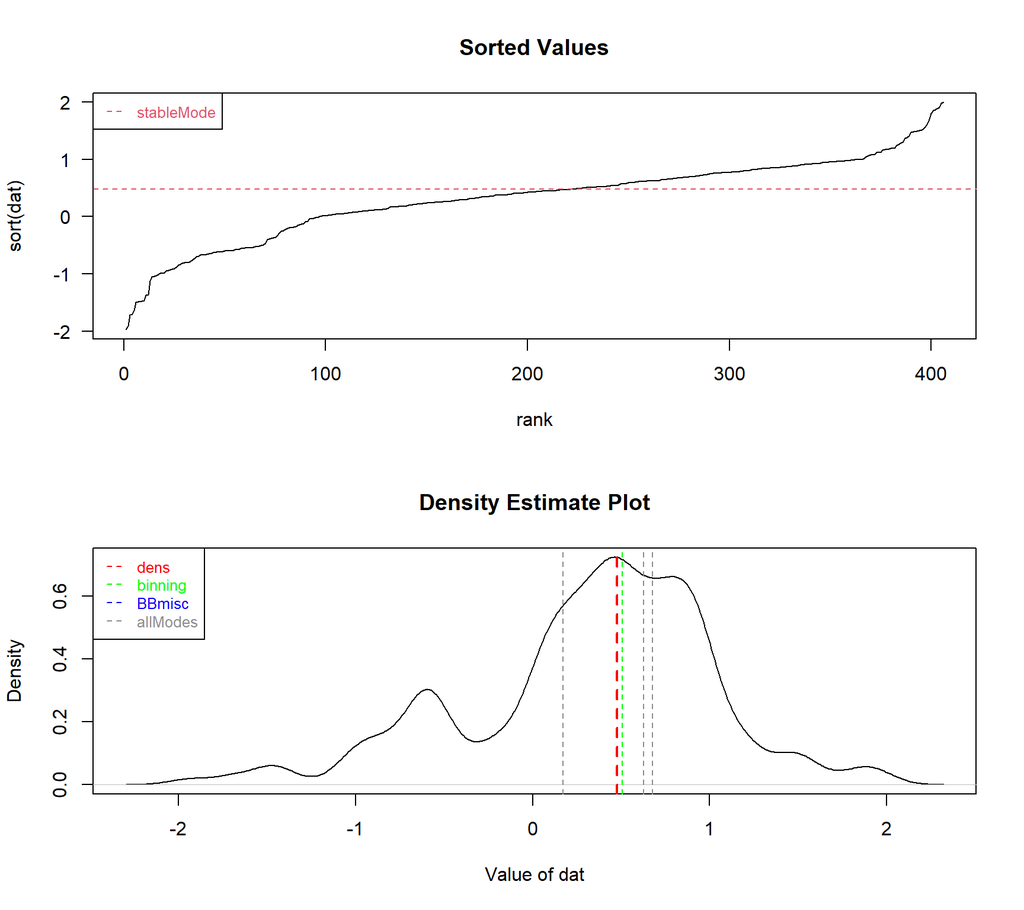

```r
layout(1:2)
plot(1:length(dat), sort(dat), type="l", main="Sorted Values", xlab="rank", las=1)
abline(h=stableMode(dat, silent=TRUE), lty=2,col=2)
legend("topleft",c("stableMode"), text.col=2, col=2, lty=2, lwd=1, seg.len=1.2, cex=0.8, xjust=0, yjust=0.5)


plot(density(dat, kernel="gaussian", adjust=0.7), xlab="Value of dat", main="Density Estimate Plot")
useCol <- c("red","green","blue","grey55")
legend("topleft",c("dens","binning","BBmisc","allModes"), text.col=useCol, col=useCol,
  lty=2, lwd=1, seg.len=1.2, cex=0.8, xjust=0, yjust=0.5)
abline(v=stableMode(dat, method="dens", silent=TRUE), lty=2, col="red", lwd=2)
abline(v=stableMode(dat, method="binning", silent=TRUE), lty=2, col="green")
abline(v=stableMode(dat, method="BBmisc", silent=TRUE), lty=2, col="blue")
abline(v=stableMode(dat, method="allModes"), lty=2, col="grey55")
```

Please note, that plotting data modelled via a Kernell function (as above) also relies on strong hypothesis which may not be well justified in a number of cases ! For this reason, the *sorted values* were plotted, too.

As you can see from this example above, looking for the most frequent exact value may not be a perfect choice for continous data. In this example the method *‘allModes’* (ie the multiple instances of most frequent exact values) gave partially usable results (dashed grey lines), due to the rounding to 3 digits. As you can see in the example above, the method *‘allModes’* may give multiple ties ! More rounding will make to data more discrete and ultimately ressemble cunting data. However, with rounding some of the finer resolution/details will get lost.

### Most Frequently Occuring Value (traditional mode)

The function `stableMode()` can also be used to locate *the* most frequently occuring exact value of numeric or character vectors. As we just saw at the end of the previous example, the argument *method=“allModes”* allows finding all ties (if present).

```r
set.seed(2021)
x <- sample(letters, 50000, replace=TRUE)
stableMode(dat, method="mode")
```

```
## [1] 0.173
```

```r
stableMode(dat, method="allModes")
```

```
## [1] 0.173 0.629 0.676
```

## Text-Manipulations

There are several packages offering interesting functions for manipulating text. Here are a few functions to complement these.

### Trimming Redundant Text

Automatic annotation has the tendency to concatenate many parameters into a single names. The function `trimRedundText()` was designed to allow trimming redundant text from left and/or right side of a character-vector (when the same portion of text appears in *each* element). However, as in some cases (like the first element of the example below) nothing would remain, it is possible to define a *minimum* width for the remaining/resulting text.

```r
txt1 <- c("abcd","abcde","abcdefg","abcdE",NA,"abcdEF")
trimRedundText(txt1)
```

```
## [1] "abcd"    "abcde"   "abcdefg" "abcdE"   NA        "abcdEF"
```

### Extract Common Part Of Text

The original idea was to do something resembling the inverse process of trimming redundant text (example above), but this time to discard the variable text.

In the end this is not as trivial when ‘common’ or ‘redundant’ text is not at the beginning or end of a chain of characters. In particular with very large text this is an active field of research (eg for sequence alignment). The function presented here is a very light-weight solution designed for smaller and simple settings, like inspecting column-names. Furthermore, the function `keepCommonText()` only reports the first (longest) hit. So, when there are multiple conserved ‘words’ of equal length, only the first of them will be identified.

When setting the argument ‘hiResol=FALSE’ this function has an option to decrease the resulution of searching, which in turn increases the speed, howevere, at cost of missing the optimal solution. In this case the resultant chain of characters should be inspected if it can be further extended/optimized.

With terminal common text :

```r
txt1 <- c("abcd","abcde","abcdefg","abcdE",NA,"abcdEF")
trimRedundText(txt1, side="left")         # remove redundant
```

```
## [1] "abcd"    "abcde"   "abcdefg" "abcdE"   NA        "abcdEF"
```

```r
keepCommonText(txt1, side="terminal")     # keep redundant
```

```
## [1] "abc"
```

```r
keepCommonText(txt1, side="center")       # computationally easier
```

```
## [1] "ab"
```

With internal coomon text:

```r
txt2 <- c("abcd_abc_kjh", "bcd_abc123", "cd_abc_po")
keepCommonText(txt2, side="center")
```

```
## [1] "cd_abc"
```

### Manipulating Enumerator-Extensions

Human operators may have many ways to write enumerators like ‘xx_sample_1’, ‘xx_Sample_2’, ‘xx_s3’, ‘xx_4’, etc. Many times you may find such text as names or column-names for measures underneith.

The functions presented below will work only if *consistent numerators*, ie (text +) digit-character(s) are at the end of all character-strings to be treated.

Please note, that with large vectors testing/checking a larger panel of enumerator-abreviations may result in slower performance. In cases of such larger data-sets it may be more effective to first study the data and then run simple subsitions using *sub()* targeted for this very case.

#### Remove/Modify Enumerators

The aim of this function consists in identifying a *common* pattern for terminal enumeratos (ie at end of words/character strings) and to subsequently modify or remove them. As separator-symbols and separator-words are given indedently all combinations thereof may be tested. Furthermore the user has the choice to (automatically) all truncated versions of separator-words (eg *Sam* instead of *Sample*).

As basic setting `rmEnumeratorName()` allows to identify and then modify a *common* terminal enumerator from all elements of a character string :

```r
xx <- c("hg_Re1","hjRe2_Re2","hk-Re3_Re33")
rmEnumeratorName(xx)
```

```
## [1] "hg1"      "hjRe22"   "hk-Re333"
```

```r
rmEnumeratorName(xx, newSep="--")
```

```
## [1] "hg--1"      "hjRe2--2"   "hk-Re3--33"
```

```r
rmEnumeratorName(xx, incl="anyCase")
```

```
## rmEnumeratorName : No conistent enumerator+digit combination found; nothing to do ..
```

```
## [1] "hg_Re1"      "hjRe2_Re2"   "hk-Re3_Re33"
```

Furthermore, this function allows scanning a matrix of text-data and to perform similar operations to the *first* column found containing a *common* terminal enumerator.

```r
xy <- cbind(a=11:13, b=c("11#11","2_No2","333_samp333"), c=xx)
rmEnumeratorName(xy)
```

```
##      a    b             c
## [1,] "11" "11#11"       "hg1"
## [2,] "12" "2_No2"       "hjRe22"
## [3,] "13" "333_samp333" "hk-Re333"
```

```r
rmEnumeratorName(xy,incl=c("anyCase","trim2","rmEnumL"))
```

```
## $dat
##      a    b             c
## [1,] "11" "11#11"       "hg"
## [2,] "12" "2_No2"       "hjRe2"
## [3,] "13" "333_samp333" "hk-Re3"
##
## $column
## [1] 3
##
## $pattern
## [1] "_Re"
```

If you which to remove/subsitute mutiple types of enumerators the function must be run independently, see last example below.

```r
xz <- cbind(a=11:13, b=c("23#11","4#2","567#333"), c=xx)
apply(xz, 2, rmEnumeratorName, sepEnum=c("","_"), newSep="_", silent=TRUE)
```

```
##      a    b         c
## [1,] "11" "23_11"   "hg_1"
## [2,] "12" "4_2"     "hjRe2_2"
## [3,] "13" "567_333" "hk-Re3_33"
```

#### Unify Enumerators

The (slightly older) function `unifyEnumerator()` offers less options, in particular the potential separator-words must be given explicitly, only lower/upper-case may be kept flexible.

```r
unifyEnumerator(c("ab-1","ab-2","c-3"))
```

```
## [1] "ab-" "ab-" "c-"
```

```r
unifyEnumerator(c("ab-R1","ab-R2","c-R3"))
```

```
## [1] "ab-R" "ab-R" "c-R"
```

```r
unifyEnumerator(c("ab-1","c3-2","dR3"), stringentMatch=FALSE)
```

```
## [1] "ab-" "c3-" "dR"
```

### Adjust Decimal Prefixes And Extact Numeric+Unit Part

The function `adjustDecPrefix()` provides help extracting the numeric part of character vectors and allows adjusting to a single million-unit type. This can be used to convert a vector of mixed prefixes like ‘z’,‘a’,‘f’,‘p’,‘n’,‘u’ and ‘m’ (note the ‘u’ is used for ‘micro’).

```r
adjustDecPrefix(c("10.psec","2 fsec"), unit="sec")
```

```
## 10000fsec     2fsec
##     10000         2
```

```r
adjustDecPrefix(c("10.psec abc","2 fsec etc"), unit="sec")
```

```
## 10000fsec     2fsec
##     10000         2
```

### Merging Multiple Named Vectors To Matrix

The function `mergeVectors()` allows merging for multiple named vectors (each element needs to be named). Basically, all elements carrying the same name across different input-vectors will be aligned in the same column of the output (input-vectors appear as lines). If *match()* is not successful, the function will try *grep()* to find matches. Different to *merge()* which allows merging only 2 data.frames, here multiple vectors may be merge at once.

```r
x1 <- c(a=1, b=11, c=21)
x2 <- c(b=12, c=22, a=2)
x3 <- c(a=3, d=43)
mergeVectors(vect1=x1, vect2=x2, vect3=x3)
```

```
##       a  b  c  d
## vect1 1 11 21 NA
## vect2 2 12 22 NA
## vect3 3 NA NA 43
```

```r
mergeVectors(vect1=x1, vect2=x2, vect3=x3, inclInfo=TRUE)   # return list with additional info
```

[output not shown]

```
##       a  b  c  d
## vect1 1 11 21 NA
## vect2 2 12 22 NA
## vect3 3 NA NA 43
```

Furthermore, when merging is (still) not successful, common enumerator-names will be stripped to enhance chances of better merging.

```r
x11 <- c(Noa=1, Numberb=11, Samplec=21)
x12 <- c(Nob=12, Numberc=22, Samplea=2)
x13 <- c(Numbera=3, d=43)
mergeVectors(vect1=x11, vect2=x12, vect3=x13)
```

```
##        d Noa Nob Numbera Numberb Numberc Samplea Samplec
## vect1 NA   1  NA      NA      11      NA      NA      21
## vect2 NA  NA  12      NA      NA      22       2      NA
## vect3 43  NA  NA       3      NA      NA      NA      NA
```

```r
x4 <- 41:44     # no names - not conform for merging
mergeVectors(x1, x2, x3, x4)
```

```
## mergeVectors :  Vectors must be longer than 0 and must have names on each element for merging; omit 1 (out of 4) vector(s)
```

```
##     a  b  c  d
## x.1 1 11 21 NA
## x.2 2 12 22 NA
## x.3 3 NA NA 43
```

### Match All Lines of Matrix To Reference Note

This function allows adjusting the order of lines of a matrix to a reference character-vector , even when initial direct matching of character-strings using is not possible/successful. In this case, various variants of using will be used to see if unambiguous matching is possible of characteristic parts of the text. All columns of will be tested an the column giving the bes resuts will be used.

```r
## Note : columns b and e allow non-ambigous match, not all elements of e are present in a
mat0 <- cbind(a=c("mvvk","axxd","bxxd","vv"),b=c("iwwy","iyyu","kvvh","gxx"), c=rep(9,4),
  d=c("hgf","hgf","vxc","nvnn"), e=c("_vv_","_ww_","_xx_","_yy_"))
matchMatrixLinesToRef(mat0[,1:4], ref=mat0[,5])
```

```
##      a      b      c   d      c   ref
## [1,] "bxxd" "kvvh" "9" "vxc"  "9" "_vv_"
## [2,] "mvvk" "iwwy" "9" "hgf"  "9" "_ww_"
## [3,] "vv"   "gxx"  "9" "nvnn" "9" "_xx_"
## [4,] "axxd" "iyyu" "9" "hgf"  "9" "_yy_"
```

```r
matchMatrixLinesToRef(mat0[,1:4], ref=mat0[1:3,5], inclInfo=TRUE)
```

```
## $mat
##      a      b      c   d      c   ref
## [1,] "bxxd" "kvvh" "9" "vxc"  "9" "_vv_"
## [2,] "mvvk" "iwwy" "9" "hgf"  "9" "_ww_"
## [3,] "vv"   "gxx"  "9" "nvnn" "9" "_xx_"
##
## $byColumn
## [1] 2
##
## $newOrder
## vv ww xx
##  3  1  4
##
## $method
## [1] "grep of ref after trimming redundant text"
```

```r
matchMatrixLinesToRef(mat0[,-2], ref=mat0[,2], inclInfo=TRUE)   # needs 'reverse grep'
```

```
## matchMatrixLinesToRef : rmEnumeratorName : Invalid or empty input; nothing to do ..
## matchMatrixLinesToRef : rmEnumeratorName : Invalid or empty input; nothing to do ..
## matchMatrixLinesToRef : rmEnumeratorName : Invalid or empty input; nothing to do ..
```

```
## $mat
##      a      c   d      e      ref
## [1,] "axxd" "9" "hgf"  "_ww_" "iwwy"
## [2,] "vv"   "9" "nvnn" "_yy_" "iyyu"
## [3,] "mvvk" "9" "hgf"  "_vv_" "kvvh"
## [4,] "bxxd" "9" "vxc"  "_xx_" "gxx"
##
## $byColumn
## [1] 4
##
## $newOrder
## [1] 2 4 1 3
##
## $method
## [1] "Reverse grep after trimming redundant text"
```

### Order Matrix According To Reference

The function `orderMatrToRef()` has the aim of facilitating brining a matrix of text/data in the order of a given reference (character vector). This function will try all columns of the input-matrix to see which gives the best coverage/ highest number of matches to the reference. If no hits are found, this function will try by partial matching (using *grep()*) all entries of the reference and vice-versa all entries of the matrix.

```r
mat1 <- matrix(paste0("__",letters[rep(c(1,1,2,2,3),3) +rep(0:2,each=5)], rep(1:5)), ncol=3)
orderMatrToRef(mat1, paste0(letters[c(3,4,5,3,4)],c(1,3,5,2,4)))
```

```
## $by
## [1] "mat"
##
## $colNo
## [1] 3
##
## $le
## c1 d3 e5 c2 d4
##  1  1  1  1  1
##
## $ord
## [1] 1 4 2 5 3
##
## $mat
##                           ref
## [1,] "__a1" "__b1" "__c1" "c1"
## [2,] "__b4" "__c4" "__d4" "d3"
## [3,] "__a2" "__b2" "__c2" "e5"
## [4,] "__c5" "__d5" "__e5" "c2"
## [5,] "__b3" "__c3" "__d3" "d4"
```

```r
mat2 <- matrix(paste0("__",letters[rep(c(1,1,2,2,3),3) +rep(0:2,each=5)], c(rep(1:5,2),1,1,3:5 )), ncol=3)
orderMatrToRef(mat2, paste0(letters[c(3,4,5,3,4)],c(1,3,5,1,4)))
```

```
## $by
## [1] "ref"
##
## $colNo
## [1] 3
##
## $le
## c1 d3 e5 c1 d4
##  2  1  1  2  1
##
## $ord
## c1 d3 e5 c1 d4
##  1  3  5  2  4
##
## $mat
##                           ref
## [1,] "__a1" "__b1" "__c1" "c1"
## [2,] "__b3" "__c3" "__d3" "d3"
## [3,] "__c5" "__d5" "__e5" "e5"
## [4,] "__a2" "__b2" "__c1" "c1"
## [5,] "__b4" "__c4" "__d4" "d4"
```

```r
mat3 <- matrix(paste0(letters[rep(c(1,1,2,2,3),3) +rep(0:2,each=5)], c(rep(1:5,2),1,1,3,3,5 )), ncol=3)
orderMatrToRef(mat3, paste0("__",letters[c(3,4,5,3,4)],c(1,3,5,1,3)))
```

```
## $by
## [1] "mat"
##
## $colNo
## [1] 3
##
## $le
## a1 a2 b3 b4 c5
##  2  2  2  2  1
##
## $ord
## [1] 1 3 5 2 4
##
## $mat
##                     ref
## [1,] "a1" "b1" "c1" "__c1"
## [2,] "b3" "c3" "d3" "__d3"
## [3,] "c5" "d5" "e5" "__e5"
## [4,] "a2" "b2" "c1" "__c1"
## [5,] "b4" "c4" "d3" "__d3"
```

### Value Matching With Option For Concatenated Terms

Sometimes we need to match terms in concatenated tables. The function `concatMatch()` was designed to behave similar to *match()* but also allowing to serach among concatenated terms and some further text-simplifications.

```r
## simple example without concatenations or text-extensions
x0 <- c("ZZ","YY","AA","BB","DD","CC","D")
tab0 <- c("AA","BB,E","CC","FF,U")
match(x0, tab0)
```

```
## [1] NA NA  1 NA NA  3 NA
```

```r
concatMatch(x0, tab0)         # same result as match(), but with names
```

```
## ZZ YY AA BB DD CC  D
## NA NA  1  2 NA  3 NA
```

```r
## now let's construct somthing similar but with concatenations and text-extensions
x1 <- c("ZZ","YY","AA","BB-2","DD","CCdef","Dxy")            # modif of single ID (no concat)
tab1 <- c("AA","WW,Vde,BB-5,E","CCab","FF,Uef")
match(x1, tab1)                   # match finds only the 'simplest' case (ie "AA")
```

```
## [1] NA NA  1 NA NA NA NA
```

```r
concatMatch(x1, tab1)             # finds all hits as in example above
```

```
## ZZ YY AA BB DD CC  D
## NA NA  1  2 NA  3 NA
```

```r
x2 <- c("ZZ,Z","YY,Y","AA,Z,Y","BB-2","DD","X,CCdef","Dxy")  # conatenated in 'x'
tab2 <- c("AA","WW,Vde,BB-5,E","CCab,WW","FF,UU")
concatMatch(x2, tab2)               # concatenation in both 'x' and 'table'
```

```
##   ZZ,Z   YY,Y AA,Z,Y     BB     DD   X,CC      D
##     NA     NA      1      2     NA      3     NA
```

### Check for (Strict) Order

Thi function `checkStrictOrder()` was designed to scan each line of an (numeric) input matrix for up- down- or equal-development, ie the chang to the next value on the right. For example when working with a matrix of with 4 columns one can look 3 times a the neighbour value following to the right (in the same line), thus the output will mention 3 events (for each line). If *all counts* are ‘up’ and 0 counts are ‘down’ or ‘eq’, the line follows a permanently increase (not necessarily linear), etc.

In some automated procedures (where the numer of columns of initial input may vary) it may be easier to test if any 0 occur. For this reason the argument *invertCount* was introduced, in this case a line with a ‘0’ occurring characterizes a constant behaviour (for the respective column).

```r
set.seed(2005); mat1 <- rbind(matrix(round(runif(40),1),nc=4), rep(1,4))
head(mat1)
```

```
##      [,1] [,2] [,3] [,4]
## [1,]  0.8  0.5  0.2  0.0
## [2,]  0.1  0.6  0.9  1.0
## [3,]  0.9  0.4  0.5  0.8
## [4,]  0.1  0.0  0.2  0.5
## [5,]  0.7  0.6  0.4  0.7
## [6,]  0.7  0.8  0.3  0.7
```

```r
checkStrictOrder(mat1); mat1[which(checkStrictOrder(mat1)[,2]==0),]
```

```
##       up down eq
##  [1,]  0    3  0
##  [2,]  3    0  0
##  [3,]  2    1  0
##  [4,]  2    1  0
##  [5,]  1    2  0
##  [6,]  2    1  0
##  [7,]  1    2  0
##  [8,]  2    1  0
##  [9,]  1    2  0
## [10,]  2    1  0
## [11,]  0    0  3
```

```
##      [,1] [,2] [,3] [,4]
## [1,]  0.1  0.6  0.9    1
## [2,]  1.0  1.0  1.0    1
```

A slightly more general way of testing can be done using `checkGrpOrder()`. Here, simlpy a logical value will produced for each line of input indicating if there is constant behaviour. When the argument *revRank=TRUE* (default) constant up- or constant down-characteristics will be tested

```r
head(mat1)
```

```
##      [,1] [,2] [,3] [,4]
## [1,]  0.8  0.5  0.2  0.0
## [2,]  0.1  0.6  0.9  1.0
## [3,]  0.9  0.4  0.5  0.8
## [4,]  0.1  0.0  0.2  0.5
## [5,]  0.7  0.6  0.4  0.7
## [6,]  0.7  0.8  0.3  0.7
```

```r
checkGrpOrder(mat1)
```

```
##  [1]  TRUE  TRUE FALSE FALSE FALSE FALSE FALSE FALSE FALSE FALSE  TRUE
```

```r
checkGrpOrder(mat1, revRank=FALSE)    # only constant 'up' tested
```

```
##  [1] FALSE  TRUE FALSE FALSE FALSE FALSE FALSE FALSE FALSE FALSE  TRUE
```

## Working With Regressions

### Best Starting Point For Linear Regressions (Start of linearity)

In many types of measurments the very low level measures are delicate. Especially when the readout starts with a baseline signal before increasing amounts of the analyte start producing a linear relationship. In such cases some of the very lowest levels of the analyte are masked by the (random) baseline signal. The function `linModelSelect()` presented here allows omitting some of the lowest analyte measures to focus on the linear part of the dose-response relationship.

```
## linModelSelect :  best slope pVal starting at level no 3
```

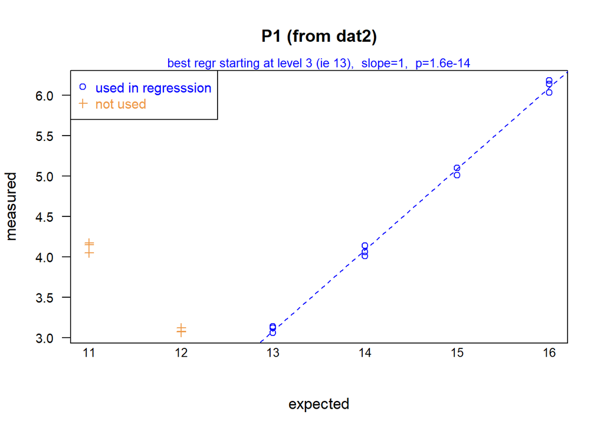

```
## $coef
##              Estimate Std. Error   t value     Pr(>|t|)
## (Intercept) -9.952667 0.22137502 -44.95840 7.131292e-13
## conc         1.003000 0.01522206  65.89121 1.578505e-14
##
## $name
## [1] "P1"
##
## $startLev
## [1] 3
```

```r
li1 <- rep(c(4,3,3:6), each=3) + round(runif(18)/5,2)
names(li1) <- paste0(rep(letters[1:5], each=3), rep(1:3,6))
li2 <- rep(c(6,3:7), each=3) + round(runif(18)/5, 2)
dat2 <- rbind(P1=li1, P2=li2)
exp2 <- rep(c(11:16), each=3)
exp4 <- rep(c(3,10,30,100,300,1000), each=3)

## Check & plot for linear model
linModelSelect("P1", dat2, expect=exp2)
```

```r
linModelSelect("P2", dat2, expect=exp2)
```

```
## linModelSelect :  best slope pVal starting at level no 2
```

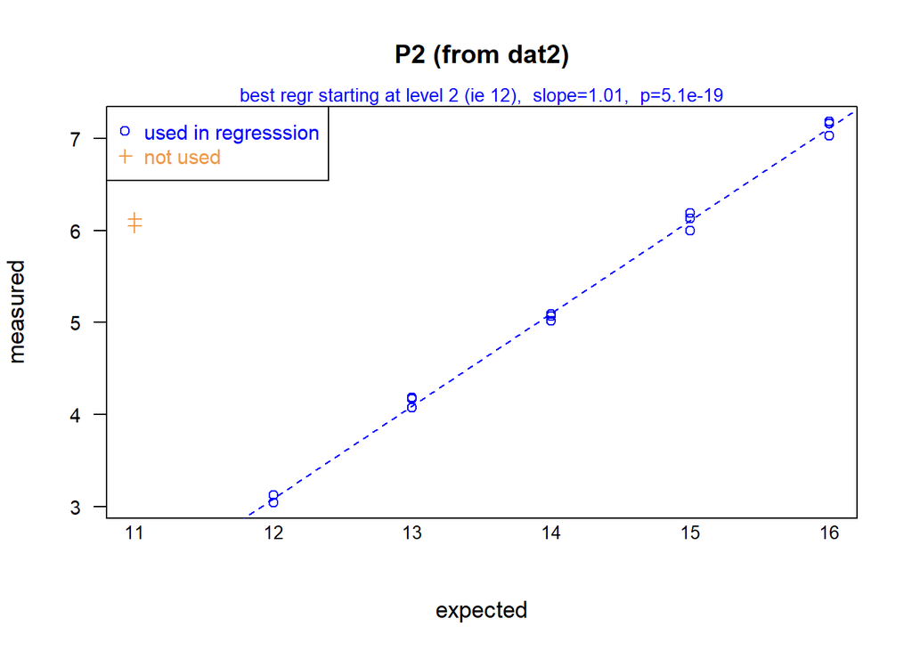

```
## $coef
##              Estimate Std. Error   t value     Pr(>|t|)
## (Intercept) -9.012667 0.17332584 -51.99840 1.806130e-16
## conc         1.008000 0.01231773  81.83325 5.058935e-19
##
## $name
## [1] "P2"
##
## $startLev
## [1] 2
```

This function was designed for use with rather small data-sets with no (or very few) measures of base-line. When larger panels of data ara available, it may be better to first define a confidence interval for the base-line measurement and then only to consider points outside this confidence interval for regressing dose-response relationships (see also [Detection limit](https://en.wikipedia.org/wiki/Detection_limit)).

### High Throughput Testing For Linear Regressions

Once we have run multiple linear regressions on differt parts of the data we might wat to compare them in a single plot. Below, we construct 10 series of data that get modeled the same way, ideally one would obtain a slope close to 1.0. We still allow omitting some starting points, if the resulting model would fit better.

```r
set.seed(2020)
x1 <- matrix(rep(c(2,2:5),each=20) + runif(100) +rep(c(0,0.5,2:3,5),20),
  byrow=FALSE, ncol=10, dimnames=list(LETTERS[1:10],NULL))
## just the 1st regression :
   summary(lm(b~a, data=data.frame(b=x1[,1], a=rep(1:5,each=2))))
```

```
##
## Call:
## lm(formula = b ~ a, data = data.frame(b = x1[, 1], a = rep(1:5,
##     each = 2)))
##
## Residuals:
##     Min      1Q  Median      3Q     Max
## -2.3811 -0.6719 -0.5001  1.3683  2.6876
##
## Coefficients:
##             Estimate Std. Error t value Pr(>|t|)
## (Intercept)   2.7850     1.3668   2.038   0.0759 .
## a             0.5545     0.4121   1.346   0.2153
## ---
## Signif. codes:  0 '***' 0.001 '**' 0.01 '*' 0.05 '.' 0.1 ' ' 1
##
## Residual standard error: 1.843 on 8 degrees of freedom
## Multiple R-squared:  0.1846, Adjusted R-squared:  0.08263
## F-statistic: 1.811 on 1 and 8 DF,  p-value: 0.2153
```

```r
## all regressions
x1.lmSum <- t(sapply(lapply(rownames(x1), linModelSelect, dat=x1,
  expect=rep(1:5,each=2), silent=TRUE, plotGraph=FALSE),
  function(x) c(x$coef[2,c(4,1)], startFr=x$startLev)))
x1.lmSum <- cbind(x1.lmSum, medQuantity=apply(x1,1,median))
x1.lmSum[,1] <- log10(x1.lmSum[,1])
head(x1.lmSum)
```

```
##    Pr(>|t|)  Estimate startFr medQuantity
## A -4.298797 0.7837628       1    3.781966
## B -4.828403 1.1542815       2    3.756802
## C -5.873269 0.6638477       1    5.883383
## D -6.518075 0.7793624       1    6.703049
## E -5.288792 0.8599269       1    8.725195
## F -5.031322 0.9901120       2    3.286851
```

Now we can try to plot :

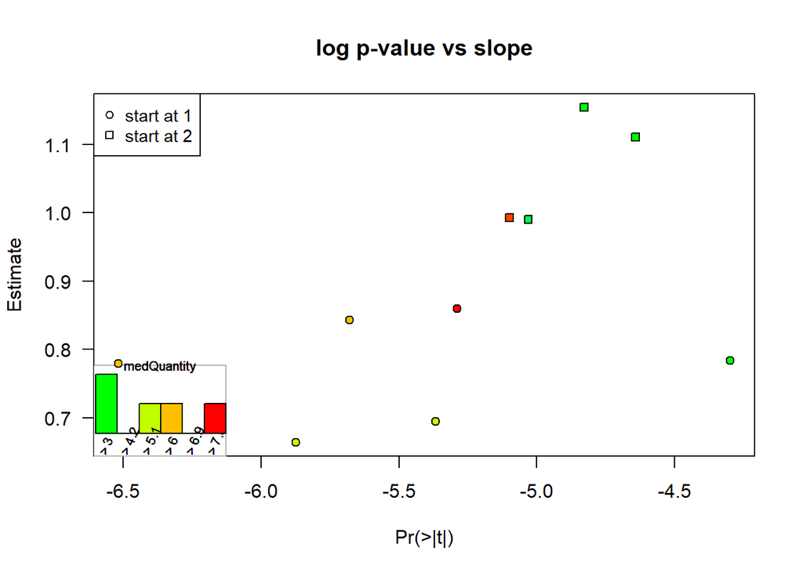

```r
wrGraphOK <- requireNamespace("wrGraph", quietly=TRUE)      # check if package is available
if(wrGraphOK) wrGraph::plotW2Leg(x1.lmSum, useCol=c("Pr(>|t|)","Estimate","medQuantity","startFr"),
  legendloc="topleft", txtLegend="start at")
```

## Combinatorics Issues

### All Pairwise Ratios

`ratioAllComb()` calculates all possible pairwise ratios between all individual calues of x and y.

```r
set.seed(2014); ra1 <- c(rnorm(9,2,1), runif(8,1,2))
```

Let’s assume there are 2 parts of ‘x’ for which we would like to know the representative ratio : The ratio of medians does not well reflect the typical ratio (if each element has the same chance to be picked).

```r
median(ra1[1:9]) / median(ra1[10:17])
```

```
## [1] 1.327086
```

Instead, we’ll build all possible ratios and summarize then.

```r
summary( ratioAllComb(ra1[1:9], ra1[10:17]))
```

```
##    Min. 1st Qu.  Median    Mean 3rd Qu.    Max.
##   0.359   1.142   1.274   1.290   1.506   2.777
```

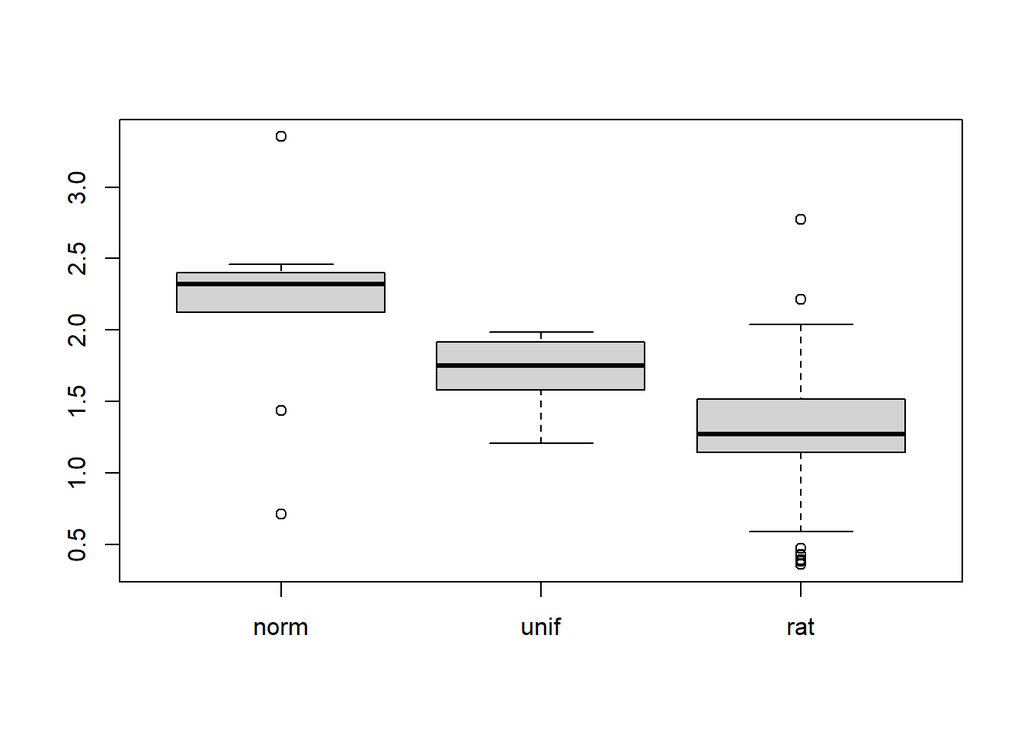

```r
boxplot(list(norm=ra1[1:9], unif=ra1[10:17], rat=ratioAllComb(ra1[1:9],ra1[10:17])))
```

### Count Frequency Of Terms Combined From Different Drawings (combineAsN)

The main idea of this function is to count frequency of terms when combining different drawings. Suppose, you are asking students for their prefered hobbies. Now, you want to know how many terms will occur in common in groups of 3 students. In the example below, simple letters are shown instead of names of hobbies …

In the simplest way of using `combineAsN()` does something similar to *table* : Here we’re looking at the full combinatorics of making groups of *nCombin* students and let’s count the frequency of terms found 3 times identical, 2 times or only once (ie not cited by the others). In case multiple groups of *nCombin* students can be formed, the average of the counts, standard error of the mean (sem), 95% confidence interval (CI) and sd aregiven to resume the results.

```r
tm1 <- list(a1=LETTERS[1:7], a2=LETTERS[3:9], a3=LETTERS[6:10], a4=LETTERS[8:12])
combineAsN(tm1, nCombin=3, lev=gl(1,4))[,1,]
```

```
##       n       sem       CI       sd
## sing  5 0.8164966 2.598457 1.632993
## doub  5 0.8164966 2.598457 1.632993
## trip  1 0.5773503 1.837386 1.154701
## min2 10 1.1547005 3.674772 2.309401
## any  11 0.5773503 1.837386 1.154701
```

One may imagine that different locations/coties/countries will give different results. Thus, we’ll declare the different origins/location using the *lev* argument. Now, this function focusses (by default) on combinations of students from *nCombin* different origins/location and counts how many hobbies were mentioned as all different (‘sing’, ie number of hobbies only one student mentioned), single repeat (‘doub’) or three times repeated (‘trip’), plus minumum twice or ‘any’ (ie number of hobies citied no matter how many repeats). The output is an array, the 3rd dimension contains the counts, fllowed by sem, CI and sd.

```r
## different levels/groups in list-elements
tm4 <- list(a1=LETTERS[1:15], a2=LETTERS[3:16], a3=LETTERS[6:17], a4=LETTERS[8:19],
  b1=LETTERS[5:19], b2=LETTERS[7:20], b3=LETTERS[11:24], b4=LETTERS[13:25], c1=LETTERS[17:26],
  d1=LETTERS[4:12], d2=LETTERS[5:11], d3=LETTERS[6:12], e1=LETTERS[7:10])
te4 <- combineAsN(tm4, nCombin=4, lev=substr(names(tm4),1,1))
```

```
## combineAsN :  argument 'nCombin' combined to 'remDouble'=TRUE  is too high for given data, re-setting to 4
```

```r
str(te4)
```

```
##  num [1:5, 1:7, 1:4] 4 4 3 8 19 ...
##  - attr(*, "dimnames")=List of 3
##   ..$ : chr [1:5] "sing" "doub" "trip" "min2" ...
##   ..$ : chr [1:7] "a_a_a_a" "a_b_c_d" "a_b_c_e" "a_b_d_e" ...
##   ..$ : chr [1:4] "n" "sem" "CI" "sd"
```

```r
te4[,,1]           # the counts part only
```

```
##      a_a_a_a   a_b_c_d a_b_c_e   a_b_d_e   a_c_d_e b_b_b_b   b_c_d_e
## sing       4  6.562500  7.5000  7.437500 15.333333       3 10.333333
## doub       4 12.583333 12.5625  6.708333  4.166667       8  9.666667
## trip       3  4.395833  2.8750  3.520833  3.750000       3  2.000000
## min2       8 19.145833 20.0625 14.145833 19.500000      11 20.000000
## any       19 23.541667 22.9375 19.541667 23.250000      21 22.000000
```

## Import/Export

### Batch-Reading Of Csv Files

Some software do produce a series of csv files, where a large experiment/data-set get recorded as multiple files. The function `readCsvBatch()` was designed for reading multiple csv files of exactly the same layout and to join their content. As output a list with the content of each file can be produced (one matrix per file), or the data may be fused into an array, as shown below.

```r
path1 <- system.file("extdata", package="wrMisc")
fiNa <-  c("pl01_1.csv","pl01_2.csv","pl02_1.csv","pl02_2.csv")
datAll <- readCsvBatch(fiNa, path1, silent=TRUE)
str(datAll)
```

```
##  num [1:96, 1:4, 1] 158808 174272 183176 175752 49272 ...
##  - attr(*, "dimnames")=List of 3
##   ..$ : chr [1:96] "A01" "B01" "C01" "D01" ...
##   ..$ : chr [1:4] "1_1.csv" "1_2.csv" "2_1.csv" "2_2.csv"
##   ..$ : chr "StainA"
```

When setting the first argument *fileNames* to *NULL*, you can read all files of a given path.

```r
## batch reading of all csv files in specified path :
datAll2 <- readCsvBatch(fileNames=NULL, path=path1, silent=TRUE)
str(datAll2)
```

```
##  num [1:96, 1:4, 1] 158808 174272 183176 175752 49272 ...
##  - attr(*, "dimnames")=List of 3
##   ..$ : chr [1:96] "A01" "B01" "C01" "D01" ...
##   ..$ : chr [1:4] "1_1.csv" "1_2.csv" "2_1.csv" "2_2.csv"
##   ..$ : chr "StainA"
```

### Batch-Reading Of Tabulated Files

The function `readTabulatedBatch()` allows fast batch reading of tabulated files. All files specified (or all files from a given directory) will be read into separate data.frames of a list. Default options are US-style comma, automatic testing for head in case the package *data.table* is available (otheriwse : no header). Furthermore it is possible to design a given (numeric) column and directly filter for all lines passing a given threshold, allowing to get smaller objects.

```r
path1 <- system.file("extdata", package="wrMisc")
fiNa <-  c("a1.txt","a2.txt")
allTxt <- readTabulatedBatch(fiNa, path1)
str(allTxt)
```

```
## List of 2
##  $ a1.txt:'data.frame':  33 obs. of  3 variables:
##   ..$ V1: int [1:33] 3697 3626 732 388503 10747 1564 3699 256394 345 3950 ...
##   ..$ V2: num [1:33] 4 6.24 6.63 6.71 8 ...
##   ..$ V3: num [1:33] 0.621 0.507 0.575 0.502 0.525 ...
##  $ a2.txt:'data.frame':  35 obs. of  3 variables:
##   ..$ V1: int [1:35] 6414 57381 8404 10580 79611 4739 10252 221395 4256 4811 ...
##   ..$ V2: num [1:35] 1.73 5.83 6.71 7.48 9.49 ...
##   ..$ V3: num [1:35] 0.412 0.407 0.391 0.368 0.348 ...
```

### Reading Incomplete Tables

Sometimes were may get confronted with data which look like ‘incomplete’ tables. In such cases some rows do not contain as many elements/columns as other columns. Files with this type of data pose a problem for `read.table()` (from the *utils* package). In some cases using the argument *fill=TRUE* may allow to overcome this problem. The function *readVarColumns()* (from this package) was designed to provide better help in such cases. Basically each line is read and parsed separately, the user should check/decide on the separator to be used.

The example below lists people’s names in different locations, some locations have more persons … Sometimes exporting such data will generate shorter lines in locations with fewer elements (here ‘London’) and no additional separators will get added (to mark all empty fields) towards the end. The function `readVarColumns()` (from this package) provides help to read such data, if the content (and separators) of the last columns are missing.

```r
path1 <- system.file("extdata", package="wrMisc")
fiNa <- "Names1.tsv"
datAll <- readVarColumns(fiName=file.path(path1,fiNa), sep="\t")
```

```
## readVarColumns :  setting 'refCo' to 'Location'
```

```r
str(datAll)
```

```
##  chr [1:2, 1:5] "Paris" "London" "Caroline" "James" "Marie" "Stella" ...
##  - attr(*, "dimnames")=List of 2
##   ..$ : chr [1:2] "Paris" "London"
##   ..$ : chr [1:5] "Location" "Names" "Names_2" "Names_3" ...
```

### Converting Url For Reading Tabulated Data From GitHub

[GitHub](https://github.com/) allows sharing code and (to a lower degree) data. In order to properly read tabulated (txt, tsv or csv) data directly from a given url, the user should switch to the ‘Raw’ view. The function `gitDataUrl()` allows to conventiently switch any url (on git) to the format from ‘Raw view’, suitable for directly reading the data using *read.delim()* , *read.table()* or *read.csv()* etc …).

```r
## An example url with tabulated data :
url1 <- "https://github.com/bigbio/proteomics-metadata-standard/blob/master/annotated-projects/PXD001819/PXD001819.sdrf.tsv"
gitDataUrl(url1)
```

```
## [1] "https://raw.githubusercontent.com/bigbio/proteomics-metadata-standard/master/annotated-projects/PXD001819/PXD001819.sdrf.tsv"
```

The example below shows how this is used in the function *readSampleMetaData()* in wrProteo.

```r
dataPxd <- try(read.delim(gitDataUrl(url1), sep='\t', header=TRUE))
str(dataPxd)
```

```
## 'data.frame':    27 obs. of  24 variables:
##  $ source.name                          : chr  "Sample 1" "Sample 1" "Sample 1" "Sample 2" ...
##  $ characteristics.organism.            : chr  "Saccharomyces cerevisiae" "Saccharomyces cerevisiae" "Saccharomyces cerevisiae" "Saccharomyces cerevisiae" ...
##  $ characteristics.organism.part.       : chr  "not available" "not available" "not available" "not available" ...
##  $ characteristics.disease.             : chr  "not available" "not available" "not available" "not available" ...
##  $ characteristics.cell.type.           : chr  "not applicable" "not applicable" "not applicable" "not applicable" ...
##  $ characteristics.mass.                : chr  "2 mg" "2 mg" "2 mg" "2 mg" ...
##  $ characteristics.spiked.compound.     : chr  "CT=mixture;QY=12500 amol;CN=UPS1;CV=Standards Research Group" "CT=mixture;QY=12500 amol;CN=UPS1;CV=Standards Research Group" "CT=mixture;QY=12500 amol;CN=UPS1;CV=Standards Research Group" "CT=mixture;QY=125 amol;CN=UPS1;CV=Standards Research Group" …
##  $ characteristics.biological.replicate.: int  1 1 1 1 1 1 1 1 1 1 ...
##  $ material.type                        : chr  "lysate" "lysate" "lysate" "lysate" ...
##  $ assay.name                           : chr  "run 1" "run 2" "run 3" "run 4" ...
##  $ technology.type                      : chr  "proteomic profiling by mass spectrometry" "proteomic profiling by mass spectrometry" "proteomic profiling by mass spectrometry" "proteomic profiling by mass spectrometry" ...
##  $ comment.label.                       : chr  "AC=MS:1002038;NT=label free sample" "AC=MS:1002038;NT=label free sample" "AC=MS:1002038;NT=label free sample" "AC=MS:1002038;NT=label free sample" ...
##  $ comment.instrument.                  : chr  "AC=MS:1001742;NT=LTQ Orbitrap Velos" "AC=MS:1001742;NT=LTQ Orbitrap Velos" "AC=MS:1001742;NT=LTQ Orbitrap Velos" "AC=MS:1001742;NT=LTQ Orbitrap Velos" ...
##  $ comment.precursor.mass.tolerance.    : chr  "5 ppm" "5 ppm" "5 ppm" "5 ppm" ...
##  $ comment.fragment.mass.tolerance.     : chr  "0.8 Da" "0.8 Da" "0.8 Da" "0.8 Da" ...
##  $ comment.cleavage.agent.details.      : chr  "NT=trypsin/P;AC=MS:1001313" "NT=trypsin/P;AC=MS:1001313" "NT=trypsin/P;AC=MS:1001313" "NT=trypsin/P;AC=MS:1001313" ...
##  $ comment.modification.parameters.     : chr  "NT=Carbamidomethyl;TA=C;MT=fixed;AC=UNIMOD:4" "NT=Carbamidomethyl;TA=C;MT=fixed;AC=UNIMOD:4" "NT=Carbamidomethyl;TA=C;MT=fixed;AC=UNIMOD:4" "NT=Carbamidomethyl;TA=C;MT=fixed;AC=UNIMOD:4" ...
##  $ comment.modification.parameters..1   : chr  "NT=Oxidation;MT=variable;TA=M;AC=UNIMOD:35" "NT=Oxidation;MT=variable;TA=M;AC=UNIMOD:35" "NT=Oxidation;MT=variable;TA=M;AC=UNIMOD:35" "NT=Oxidation;MT=variable;TA=M;AC=UNIMOD:35" ...
##  $ comment.modification.parameters..2   : chr  "NT=Acetyl;AC=UNIMOD:67;PP=Protein N-term;MT=variable" "NT=Acetyl;AC=UNIMOD:67;PP=Protein N-term;MT=variable" "NT=Acetyl;AC=UNIMOD:67;PP=Protein N-term;MT=variable" "NT=Acetyl;AC=UNIMOD:67;PP=Protein N-term;MT=variable" ...
##  $ comment.technical.replicate.         : int  1 2 3 1 2 3 1 2 3 1 ...
##  $ comment.fraction.identifier.         : int  1 1 1 1 1 1 1 1 1 1 ...
##  $ comment.file.uri.                    : chr  "https://ftp.ebi.ac.uk/pride-archive/2015/12/PXD001819/UPS1_12500amol_R1.raw" "https://ftp.ebi.ac.uk/pride-archive/2015/12/PXD001819/UPS1_12500amol_R2.raw" "https://ftp.ebi.ac.uk/pride-archive/2015/12/PXD001819/UPS1_12500amol_R3.raw" "https://ftp.ebi…
##  $ comment.data.file.                   : chr  "UPS1_12500amol_R1.raw" "UPS1_12500amol_R2.raw" "UPS1_12500amol_R3.raw" "UPS1_125amol_R1.raw" ...
##  $ factor.value.spiked.compound.        : chr  "CT=mixture;QY=12500 amol;CN=UPS1;CV=Standards Research Group" "CT=mixture;QY=12500 amol;CN=UPS1;CV=Standards Research Group" "CT=mixture;QY=12500 amol;CN=UPS1;CV=Standards Research Group" "CT=mixture;QY=125 amol;CN=UPS1;CV=Standards Research Group" …
```

## Normalization

The main reason of normalization is to remove variability in the data which is not directly linked to the (original/biological) concept of a given experiment. High throughput data from real world measurements may easily contain various deformations due to technical reasons, eg slight temperature variations, electromagnetic interference, instability of reagents etc. In particular, transferring constant amounts of liquids/reagents in highly repeated steps over large experiments is often also very challenging, small variations of the amounts of liquid (or similar) are typically addressed by normalization. However, applying aggressive normalization to the data also brings considerable risk of starting to loose some of the effects one intended to study. At some point it may rather be better to eliminate a few samples or branches of an experiment to avoid too invasive intervention. This shows that quality control can be tightly linked to decisions about data-normalization. In conclusion, normalization may be far more challenging than simply running some algorithms..

In general, the use has to assume/define some hypothesis to justify intervention. Sometimes specific elements of an experiment are known to be not affected and can therefore be used to normalize the rest. Eg, if you observe growth of trees in a forest, big blocks of rock on the floor are assumed no to change their location. So one could use them as alignment-marks to superpose pictures taken at slightly different positions.

The hypothesis of no global changes is very common : During the course of many biological experiments (eg change of nutrient) one assumes that only a small portion of the elements measured (eg the abundance of all different gene-products) do change, since many processes of a living cell like growth, replication and interaction with neighbour-cells are assumed not to be affected. So, if one assumes that there are no global changes one normalizes the input-data in a way that the average or median across each experiment will give the same value. In analogy, if one takes photographs on a partially cloudy day, most cameras will adjust light settings (sun r clouds) so that global luminosity stays the same. However, if too many of the measured elements are affected, this normalization approach will lead to (additional) loss of information.

It is *essential* to understand the type of deformation(s) data may suffer from in order to choose the appropriate approacges for normalization. Of course, graphical representations ([PCA](https://en.wikipedia.org/wiki/Principal_component_analysis), [MA-plots](https://en.wikipedia.org/wiki/MA_plot), etc) are extremely important to identifying abnormalities and potential problems. The package wrGraph offers also complementary options useful in the context of normalization. Again, graphical representation(s) of the data help to visualize how different normalization procedures affect outcomes.

Before jumping into normalization it may be quite useful to *filter* the data first. The overall idea is, that most high-throughput experiments do produce some non-meaningful data (artefacts) and it may be wise to remove such ‘bad’ data first, as they may effect normalization (in particular *extreme values*). A special case of problematic data concerns *NA*-values.

### Filter Lines Of Matrix To Reduce Content Of NAs

Frequent *NA*-values may represent another potential issue. With NA-values there is no general optimal advice. To get started, you should try to investigate how and why NA-values occurred to check if there is a special ‘meaning’ to them. For example, on some measurement systems values below detection limit may be simply reported as NAs. If the lines of your data represent different features quantified (eg proteins), than lines with mostly NA-values represent features that may not be well exploited anyway. Therefore many times one tries to filter away lines of ‘bad’ data. Of course, if there is a column (sample) with an extremely high content of NAs, one should also investigate what might be particular with this column (sample), to see if one might be better of to eliminate the entire column.

Please note, that imputing *NA*-values represents another option instead of filtering and removing, multiple other packages address this in detail, too. All decisions of which approach to use should be data-driven.

#### Filter For Each Group Of Columns For Sufficient Data As Non-NA

```r
dat1 <- matrix(1:56,ncol=7)
dat1[c(2,3,4,5,6,10,12,18,19,20,22,23,26,27,28,30,31,34,38,39,50,54)] <- NA
grp1 <- gl(3,3)[-(3:4)]
dat1
```

```
##      [,1] [,2] [,3] [,4] [,5] [,6] [,7]
## [1,]    1    9   17   25   33   41   49
## [2,]   NA   NA   NA   NA   NA   42   NA
## [3,]   NA   11   NA   NA   35   43   51
## [4,]   NA   NA   NA   NA   36   44   52
## [5,]   NA   13   21   29   37   45   53
## [6,]   NA   14   NA   NA   NA   46   NA
## [7,]    7   15   NA   NA   NA   47   55
## [8,]    8   16   24   32   40   48   56
```

```r
## now let's filter
presenceGrpFilt(dat1, gr=grp1, presThr=0.75)  # stringent
```

```
##          1     2     3
## [1,]  TRUE  TRUE  TRUE
## [2,] FALSE FALSE FALSE
## [3,] FALSE FALSE  TRUE
## [4,] FALSE FALSE  TRUE
## [5,] FALSE  TRUE  TRUE
## [6,] FALSE FALSE FALSE
## [7,]  TRUE FALSE FALSE
## [8,]  TRUE  TRUE  TRUE
```

```r
presenceGrpFilt(dat1, gr=grp1, presThr=0.25)  # less stringent
```

```
##          1     2    3
## [1,]  TRUE  TRUE TRUE
## [2,] FALSE FALSE TRUE
## [3,]  TRUE FALSE TRUE
## [4,] FALSE FALSE TRUE
## [5,]  TRUE  TRUE TRUE
## [6,]  TRUE FALSE TRUE
## [7,]  TRUE FALSE TRUE
## [8,]  TRUE  TRUE TRUE
```

#### Filter As Separate Pairwise Groups Of Samples

If you want to use your data in a pair-wise view (like running t-tests on each line) the function `presenceFilt()` allows to eliminate lines containing too many *NA*-values for each pair-wise combination of the groups/levles.

```r
presenceFilt(dat1, gr=grp1, maxGr=1, ratM=0.1)
```

```
## presenceFilt :  correcting 'maxGrpMiss' for group(s) 1, 2 and 3  due to ratMaxNA=0.1
```

```
##        1-2   1-3   2-3
## [1,]  TRUE  TRUE  TRUE
## [2,] FALSE FALSE FALSE
## [3,] FALSE  TRUE  TRUE
## [4,] FALSE  TRUE  TRUE
## [5,]  TRUE  TRUE  TRUE
## [6,] FALSE FALSE FALSE
## [7,]  TRUE  TRUE FALSE
## [8,]  TRUE  TRUE  TRUE
```

```r
presenceFilt(dat1, gr=grp1, maxGr=2, rat=0.5)
```

```
## presenceFilt :  correcting 'maxGrpMiss' for group(s) 1 and 2  due to ratMaxNA=0.5
```

```
##        1-2  1-3  2-3
## [1,]  TRUE TRUE TRUE
## [2,] FALSE TRUE TRUE
## [3,]  TRUE TRUE TRUE
## [4,] FALSE TRUE TRUE
## [5,]  TRUE TRUE TRUE
## [6,]  TRUE TRUE TRUE
## [7,]  TRUE TRUE TRUE
## [8,]  TRUE TRUE TRUE
```

#### Cleaning Replicates

This procedures aims to remove (by setting to as *NA*) the most extreme of noisy replicates. Thus, it is assumed that all columns of the input matrix (or data.frame) are replicates of the other columns. The *nOutl* most distant points are identified and will be set to *NA*.

```r
(mat3 <- matrix(c(19,20,30,40, 18,19,28,39, 16,14,35,41, 17,20,30,40), ncol=4))
```

```
##      [,1] [,2] [,3] [,4]
## [1,]   19   18   16   17
## [2,]   20   19   14   20
## [3,]   30   28   35   30
## [4,]   40   39   41   40
```

```r
cleanReplicates(mat3, nOutl=1)
```

```
## cleanReplicates :  rownames of 'x' either NULL or not unique, replacing by row-numbers
```

```
## cleanReplicates : removing 1 entries in lines 2
```

```
##   [,1] [,2] [,3] [,4]
## 1   19   18   16   17
## 2   20   19   NA   20
## 3   30   28   35   30
## 4   40   39   41   40
```

```r
cleanReplicates(mat3, nOutl=3)
```

```
## cleanReplicates :  rownames of 'x' either NULL or not unique, replacing by row-numbers
```

```
## cleanReplicates : removing 3 entries in lines 1,2,3
```

```
##   [,1] [,2] [,3] [,4]
## 1   NA   18   16   17
## 2   20   19   NA   20
## 3   30   28   NA   30
## 4   40   39   41   40
```

### The Function normalizeThis()

In biological high-throughput data columns typically represent different samples, which may be organized as replicates. During high-throughput experiments thousands of (independent) elements are measured (eg abundance of gene-products), they are represented by rows. As real-world experiments are not always as perfect as we may think, small changes in the signal measured may easily happen. Thus, the aim of normalizing is to remove or reduce any trace/variability in the data not related to the original experiement but due to imperfections during detection.

Note, that some experiments may produce a considerable amount of missing data (NAs) which require special attention (dedicated developments exist in other R-packages eg in wrProteo). My general advice is to first carefully look where such missing data is observed and to pay attention to replicate measurements where a given element once was measured with a real numeric value and once as missing information (NA).

```r
set.seed(2015); rand1 <- round(runif(300) +rnorm(300,0,2),3)
dat1 <- cbind(ser1=round(100:1 +rand1[1:100]), ser2=round(1.2*(100:1 +rand1[101:200]) -2),
  ser3=round((100:1 +rand1[201:300])^1.2-3))
dat1 <- cbind(dat1, ser4=round(dat1[,1]^seq(2,5,length.out=100) +rand1[11:110],1))
## Let's introduce some NAs
dat1[dat1 <1] <- NA
## Let's get a quick overview of the data
summary(dat1)
```

```
##       ser1             ser2             ser3            ser4
##  Min.   :  2.00   Min.   :  1.00   Min.   :  1.0   Min.   :     37.5
##  1st Qu.: 26.75   1st Qu.: 28.00   1st Qu.: 50.0   1st Qu.:  67210.0
##  Median : 49.50   Median : 59.00   Median :109.0   Median : 332524.0
##  Mean   : 51.14   Mean   : 58.79   Mean   :115.1   Mean   : 542279.4
##  3rd Qu.: 76.25   3rd Qu.: 89.50   3rd Qu.:173.5   3rd Qu.: 925759.5
##  Max.   :100.00   Max.   :121.00   Max.   :263.0   Max.   :2123191.7
##                                    NA's   :1
```

```r
## some selected lines (indeed, the 4th column appears always much higher)
dat1[c(1:5,50:54,95:100),]
```

```
##       ser1 ser2 ser3      ser4
##  [1,]  100  121  251   10000.6
##  [2,]  100  117  244   11500.2
##  [3,]   99  120  263   12948.1
##  [4,]   99  120  242   14885.1
##  [5,]   97  114  236   16382.3
##  [6,]   51   60  111  892534.1
##  [7,]   48   58  109  812490.4
##  [8,]   49   55  108  982907.4
##  [9,]   50   56  107 1188787.7
## [10,]   45   47  102  915343.6
## [11,]    3    6    5     206.4
## [12,]    5    2    7    2570.0
## [13,]    8    1    3   27125.8
## [14,]    6    4    5    6975.9
## [15,]    3    3    1     237.0
## [16,]    2    1   NA      37.5
```

Our toy data may be normalized by a number of different criteria. In real applications the nature of the data and the type of deformation detected/expected will largely help deciding which normalization might be the ‘best’ choice. Here we’ll try first normalizing by the mean, ie all columns will be forced to end up with the same column-mean. The trimmed mean does not consider values at extremes (as outliers are frequently artefacts and display extreme values). When restricting even stronger which values to consider one will eventually end up with the median (3rd method used below).

```r
no1 <- normalizeThis(dat1, refGrp=1:3, meth="mean")
no2 <- normalizeThis(dat1, refGrp=1:3, meth="trimMean", trim=0.4)
no3 <- normalizeThis(dat1, refGrp=1:3, meth="median")
no4 <- normalizeThis(dat1, refGrp=1:3, meth="slope", quantFa=c(0.2,0.8))
```

It is suggested to verify normalization results by plots. Note, that [Box plots](https://en.wikipedia.org/wiki/Box_plot) may not be appropriate in some cases (eg multimodal distributions), for displaying more details you may consider using [Violin-Plots](https://en.wikipedia.org/wiki/Violin_plot) from packages vioplot or wrGraph, another option might be a (cumulated) frequency plot (eg in package wrGraph).

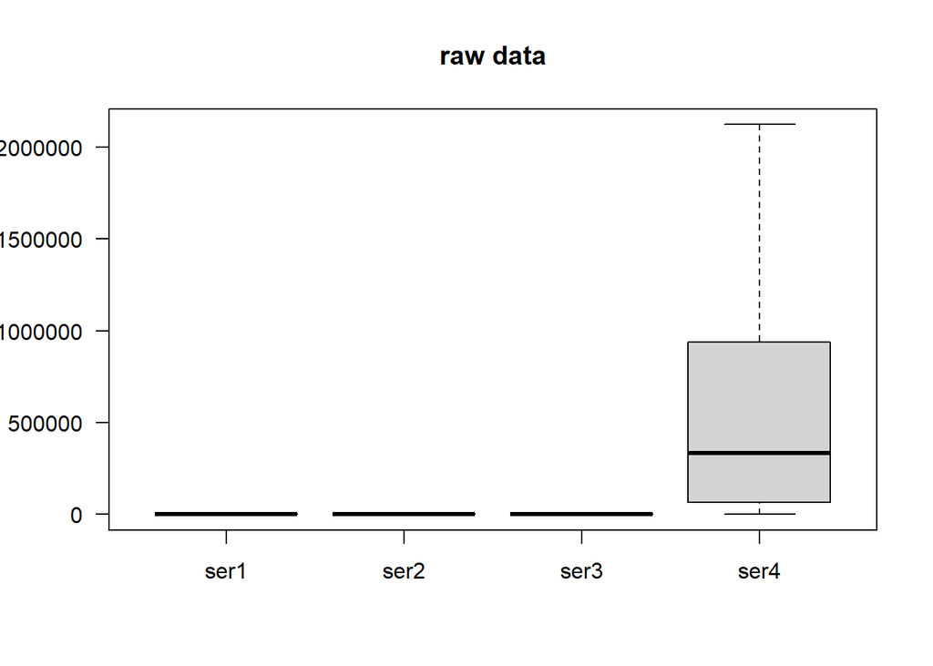

You can see clearly, that the 4th data-set has a problem of range. So we’ll see if some proportional normalization may help to make it more comparable to the other ones.

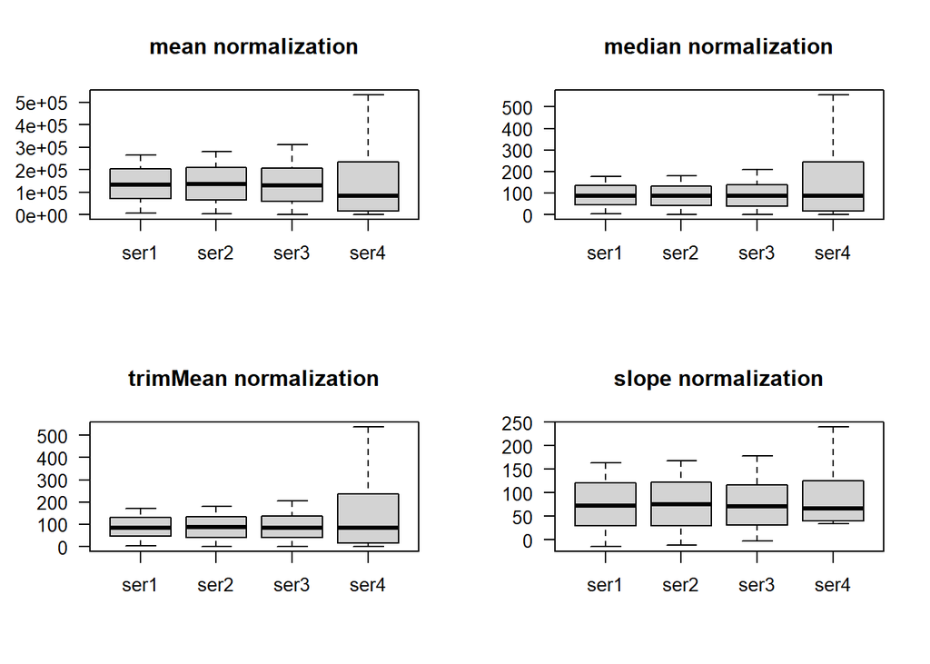

### Normalize By Rows

The standard approach for normalizing relies on consisting all columns as collections of data who’s distribution is not supposed to change. In some cases/projects we may want to formulate a much more ‘aggressive’ hypothesis : We consider the content of all columns strictly as the same. For example this may be the case when comparing with technical replicates only. In such cases one may use the function `rowNormalize()` which tries to find the average or mean optimal within-line normalization factor.

Besides, an additional mode of operation for *sparse data* has been added : Basically, once a row contains just one NA, this row can’t be used any more to derive a normalization factor for all rows. Thus, with many NA-values the number of ‘complete’ rows will be low or even 0 redering this approach inefficient or impossible. Once the content of NA-values is above a customizable threshold, the data will be broken in smaller subsets with fewer groups of fewer columns, thus increasing the chances of finding ‘complete’ subsets of data which will be normalized first and added to other subsets in later steps.

This approach relies on the **hypothesis** that *all data in a given line should be (aproximately) the same value* ! Thus, this procedure is particularly well adopted to the case when *all* samples are multiple replicate measurements of the *same* sample.

```r
set.seed(2); AA <- matrix(rbinom(110, 10, 0.05), nrow=10)
AA[,4:5] <- AA[,4:5] *rep(4:3, each=nrow(AA))

AA1 <- rowNormalize(AA)
round(AA1, 2)
```

```
##          1    2    3    4    5    6    7    8    9   10   11
##  [1,] 0.65 0.87 2.13 0.34 3.21 0.48 2.04 0.97 0.74 4.34 0.82
##  [2,] 1.72 0.87 0.80 0.34 0.29 0.48 2.04 0.97 1.98 1.00 0.82
##  [3,] 0.65 2.33 2.13 2.59 0.29 1.27 2.04 0.97 0.74 1.00 3.57
##  [4,] 0.65 0.87 0.80 2.59 0.29 2.06 0.77 0.97 0.74 1.00 2.20
##  [5,] 2.80 0.87 0.80 0.34 3.21 0.48 2.04 0.97 0.74 1.00 0.82
##  [6,] 2.80 2.33 0.80 2.59 1.75 1.27 0.77 2.59 1.98 1.00 0.82
##  [7,] 0.65 3.79 0.80 2.59 3.21 1.27 0.77 0.97 3.21 1.00 2.20
##  [8,] 1.72 0.87 0.80 0.34 0.29 2.85 0.77 2.59 0.74 1.00 0.82
##  [9,] 0.65 0.87 3.47 2.59 0.29 1.27 0.77 0.97 1.98 1.00 0.82
## [10,] 0.65 0.87 0.80 0.34 1.75 1.27 0.77 0.97 0.74 1.00 0.82
```

Now, let’s make this sparse and try normalizing:

```r
AC <- AA
AC[which(AC <1)] <- NA

(AC1 <- rowNormalize(AC))
```

```
##              1  2        3        4        5        6   7    8        9
##  [1,]       NA NA 2.343543       NA 3.870829       NA NaN   NA       NA
##  [2,] 1.388298 NA       NA       NA       NA       NA NaN   NA 3.597222
##  [3,]       NA  2 2.343543 3.499743       NA 2.663721 NaN   NA       NA
##  [4,]       NA NA       NA 3.499743       NA 5.327441  NA   NA       NA
##  [5,] 2.776596 NA       NA       NA 3.870829       NA NaN   NA       NA
##  [6,] 2.776596  2       NA 3.499743 1.935414 2.663721  NA 2.25 3.597222
##  [7,]       NA  4       NA 3.499743 3.870829 2.663721  NA   NA 7.194444
##  [8,] 1.388298 NA       NA       NA       NA 7.991162  NA 2.25       NA
##  [9,]       NA NA 4.687086 3.499743       NA 2.663721  NA   NA 3.597222
## [10,]       NA NA       NA       NA 1.935414 2.663721  NA   NA       NA
##             10       11
##  [1,] 2.583333       NA
##  [2,]       NA       NA
##  [3,]       NA 3.407407
##  [4,]       NA 1.703704
##  [5,]       NA       NA
##  [6,]       NA       NA
##  [7,]       NA 1.703704
##  [8,]       NA       NA
##  [9,]       NA       NA
## [10,]       NA       NA
```

Like with *normalizeThis()* we can define some reference-lines (only these lines will be considered to determine normalization-factors)

```r
(AC3 <- rowNormalize(AC, refLines=1:5, omitNonAlignable=TRUE))
```

```
##         1  2        3        4     5        6   7   8   9   10       11
##  [1,]  NA NA 1.909091       NA 1.750       NA NaN  NA  NA 1.75       NA
##  [2,] NaN NA       NA       NA    NA       NA NaN  NA NaN   NA       NA
##  [3,]  NA  2 1.909091 2.409836    NA 2.684932 NaN  NA  NA   NA 4.083333
##  [4,]  NA NA       NA 2.409836    NA 5.369863  NA  NA  NA   NA 2.041667
##  [5,] NaN NA       NA       NA 1.750       NA NaN  NA  NA   NA       NA
##  [6,] NaN  2       NA 2.409836 0.875 2.684932  NA NaN NaN   NA       NA
##  [7,]  NA  4       NA 2.409836 1.750 2.684932  NA  NA NaN   NA 2.041667
##  [8,] NaN NA       NA       NA    NA 8.054795  NA NaN  NA   NA       NA
##  [9,]  NA NA 3.818182 2.409836    NA 2.684932  NA  NA NaN   NA       NA
## [10,]  NA NA       NA       NA 0.875 2.684932  NA  NA  NA   NA       NA
```

Please note, that the iterative procedure for *sparse data* may consume large amounts of computational resources, in particular when a small number of subgroups has been selected.

### Matrix Coordinates Of Values/Points According To Filtering

Sometimes one needs to obtain the coordinates of values/points of a matrix according to a given filtering condition. The standard approach using *which()* gives only a *linearized* index but not row/column, which is sufficient for replacing indexed values. If you need to know the true row/column indexes, you may use `coordOfFilt()`.

```r
set.seed(2021); ma1 <- matrix(sample.int(n=40, size=27, replace=TRUE), ncol=9)
## let's test which values are >37
which(ma1 >37)      # doesn't tell which row & col
```

```
## [1]  2  3  6  7  9 14 26
```

```r
coordOfFilt(ma1, ma1 >37)
```

```
##      row col
## [1,]   2   1
## [2,]   3   1
## [3,]   3   2
## [4,]   1   3
## [5,]   3   3
## [6,]   2   5
## [7,]   2   9
```

## Statistical Testing

### Normal Random Number Generation with Close Fit to Expected mean and sd

When creating random values to an expected *mean* and *sd*, the results ontained using the standard function `rnorm()` may deviate somehow from the expected mean and sd, in particular with low *n*. To still produce random values fitting closely to the expected *mean* and *sd* you may use the function `rnormW()`. The case of *n=2* is quite simple with one possible results. In other cases (*n>2*), there will be a random initiation which can be fixed using the argument *seed*.

```r
## some sample data :
x1 <- (11:16)[-5]
mean(x1); sd(x1)
```

```
## [1] 13.2
```

```
## [1] 1.923538
```

```r
## the standard way for gerenating normal random values
ra1 <- rnorm(n=length(x1), mean=mean(x1), sd=sd(x1))
## In particular with low n, the random values deviate somehow from expected mean and sd :
mean(ra1) -mean(x1)
```

```
## [1] -1.103347
```

```r
sd(ra1) -sd(x1)
```

```
## [1] 0.3920622
```

```r
## random numbers with close fit to expected mean and sd :
ra2 <- rnormW(length(x1), mean(x1), sd(x1))
mean(ra2) -mean(x1)
```

```
## [1] 0
```

```r
sd(ra2) -sd(x1)   # much closer to expected value
```

```
## [1] -4.440892e-16
```

Thus, the second data-sets fits even with few *n* very well to the global characteristics defined/expected.

### Moderated Pair-Wise t-Test from limma

If you are not familiar with the way data is handled in the Bioconductor package [limma](https://bioconductor.org/packages/release/bioc/html/limma.html) and you would like to use some of the tools for running moderated t-tests therein, this will provide easy access using `moderTest2grp()` :

```r
set.seed(2017); t8 <- matrix(round(rnorm(1600,10,0.4),2), ncol=8,
  dimnames=list(paste("l",1:200), c("AA1","BB1","CC1","DD1","AA2","BB2","CC2","DD2")))
t8[3:6,1:2] <- t8[3:6,1:2]+3     # augment lines 3:6 for AA1&BB1
t8[5:8,5:6] <- t8[5:8,5:6]+3     # augment lines 5:8 for AA2&BB2 (c,d,g,h should be found)
t4 <- log2(t8[,1:4]/t8[,5:8])
fit4 <- moderTest2grp(t4, gl(2,2))
## now we'll use limma's topTable() function to look at the 'best' results
if("list" %in% mode(fit4)) {  # if you have limma installed we can look further
  library(limma)
  topTable(fit4, coef=1,n=5)                      # effect for 3,4,7,8
  fit4in <- moderTest2grp(t4, gl(2,2), testO="<")
  if("list" %in% mode(fit4in)) topTable(fit4in, coef=1,n=5) }
```

```
## moderTest2grp : testing alternative hypothesis: true difference in means is less than 0 (ie focus on 101 results with A less than B)
```

```
##           logFC    AveExpr         t      P.Value    adj.P.Val         B
## l 7  -0.4975806 -0.2436786 -8.712092 3.994695e-17 7.989390e-15 30.668381
## l 4   0.4020373  0.1890232  7.039234 1.000000e+00 1.000000e+00 17.723883
## l 8  -0.3735170 -0.2259811 -6.539873 9.417239e-11 9.417239e-09 14.392733
## l 3   0.3508834  0.1488240  6.143585 1.000000e+00 1.000000e+00 11.923522
## l 27 -0.1348878 -0.1011609 -2.361738 9.333949e-03 6.222633e-01 -3.878176
```

### Multiple Moderated Pair-Wise t-Tests From limma

If you want to make multiple pair-wise comparisons using `moderTestXgrp()` :

```r
grp <- factor(rep(LETTERS[c(3,1,4)], c(2,3,3)))
set.seed(2017); t8 <- matrix(round(rnorm(208*8,10,0.4),2), ncol=8,
  dimnames=list(paste(letters[], rep(1:8,each=26),sep=""), paste(grp,c(1:2,1:3,1:3),sep="")))
t8[3:6,1:2] <- t8[3:6,1:2] +3                    # augment lines 3:6 (c-f)
t8[5:8,c(1:2,6:8)] <- t8[5:8,c(1:2,6:8)] -1.5    # lower lines
t8[6:7,3:5] <- t8[6:7,3:5] +2.2                  # augment lines
## expect to find C/A in c,d,g, (h)
## expect to find C/D in c,d,e,f
## expect to find A/D in f,g,(h)
test8 <- moderTestXgrp(t8, grp)
head(test8$p.value, n=8)
```

```
##             A-C          A-D          C-D
## a1 8.736828e-02 6.776543e-02 9.397304e-01
## b1 4.384118e-01 5.400019e-01 8.205610e-01
## c1 1.094834e-19 6.344497e-01 2.571471e-21
## d1 2.671725e-13 9.915692e-01 2.858699e-13
## e1 1.802454e-03 2.413137e-08 9.735465e-16
## f1 3.188362e-01 2.527208e-32 2.226490e-22
## g1 1.166242e-29 6.410057e-33 5.484445e-01
## h1 1.141181e-05 1.943795e-05 5.674938e-01
```

### Transform p-values To Local False Discovery Rate (lfdr)

To get an introduction into local false discovery rate estimations you may read [Strimmer 2008](https://doi.org/10.1093/bioinformatics/btn209). A convenient way to get lfdr values calculated by the package fdrtool is available via the function `pVal2lfdr()`.

Note, that the toy-example used below is too small for estimating meaningful lfdr values. For this reason the function *fdrtool()* from package fdrtool will issue warnings.

```r
set.seed(2017); t8 <- matrix(round(rnorm(160,10,0.4),2), ncol=8, dimnames=list(letters[1:20],
  c("AA1","BB1","CC1","DD1","AA2","BB2","CC2","DD2")))
t8[3:6,1:2] <- t8[3:6,1:2] +3   # augment lines 3:6 (c-f) for AA1&BB1
t8[5:8,5:6] <- t8[5:8,5:6] +3   # augment lines 5:8 (e-h) for AA2&BB2 (c,d,g,h should be found)
head(pVal2lfdr(apply(t8, 1, function(x) t.test(x[1:4], x[5:8])$p.value)))
```

```
## Warning in fdrtool::fdrtool(z, statistic = "pvalue", plot = FALSE, verbose =
## !silent): There may be too few input test statistics for reliable FDR
## calculations!
```

```
##         a         b         c         d         e         f
## 1.0000000 0.5753562 0.5753562 1.0000000 1.0000000 1.0000000
```

### Confindence Intervals (under Normal Distribution)

The [confindence interval (CI)](https://en.wikipedia.org/wiki/Confidence_interval) is a common way of describing the uncertainity of measured or estimated values. The function `confInt()` allows calculating the confidence interval of the mean (using the functions *qt()* and *sd()*) under a given [significance level (alpha)](https://en.wikipedia.org/wiki/Statistical_significance). assuming that the [Normal distribution](https://en.wikipedia.org/wiki/Normal_distribution) is valid.

```r
set.seed(2022); ran <- rnorm(50)
confInt(ran, alpha=0.05)
```

```
## [1] 0.248199
```

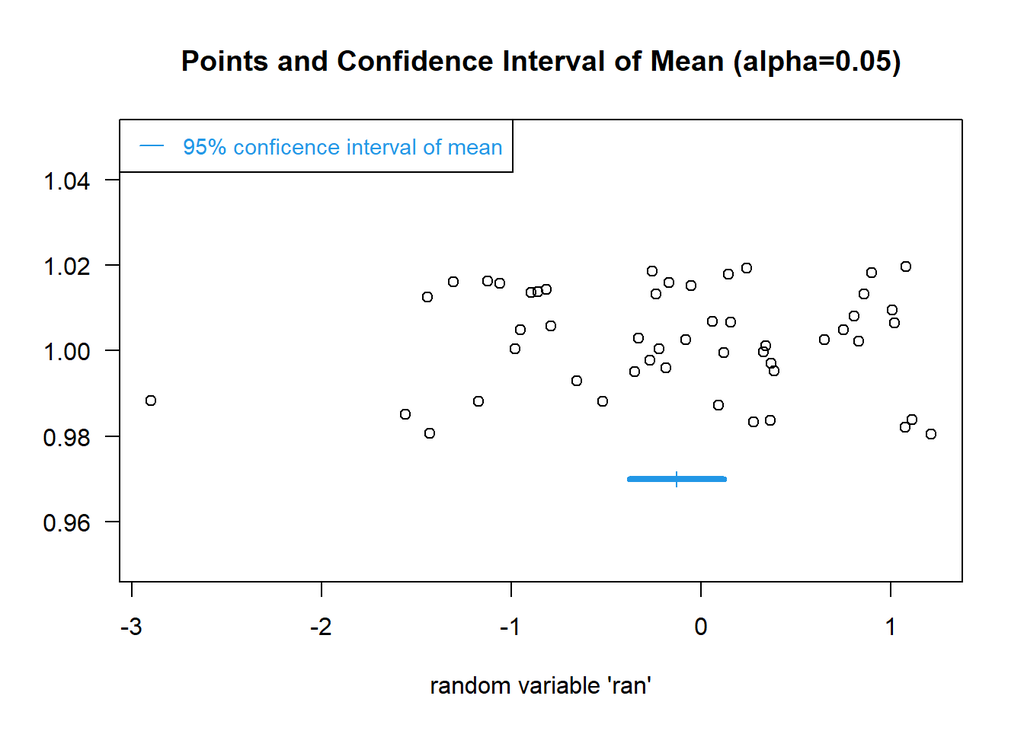

```r
## plot points and confindence interval of mean
plot(ran, jitter(rep(1, length(ran))), ylim=c(0.95, 1.05), xlab="random variable 'ran'",main="Points and Confidence Interval of Mean (alpha=0.05)", ylab="", las=1)
points(mean(ran), 0.97, pch=3, col=4)     # mean
lines(mean(ran) +c(-1, 1) *confInt(ran, 0.05), c(0.97, 0.97), lwd=4, col=4)  # CI
legend("topleft","95% conficence interval of mean", text.col=4,col=4,lty=1,lwd=1,seg.len=1.2,cex=0.9,xjust=0,yjust=0.5)
```

### Extract Groups Of Replicates From Pair-Wise Column-Names

When running multiple pairwise tests (using *moderTestXgrp()*) the column-names are concatenated group-names. To get the index of which group has been used in which pair-wise set you may use the function `matchSampToPairw()`, as shown below.

```r
## make example if limma is not installed
if(!requireNamespace("limma", quietly=TRUE)) test8 <- list(FDR=matrix(1, nrow=2, ncol=3, dimnames=list(NULL,c("A-C","A-D","C-D"))))
matchSampToPairw(unique(grp), colnames(test8$FDR))
```

```
##     le ri
## A-C  2  1
## A-D  2  3
## C-D  1  3
```

### Extract Numeric Part Of Column-Names

When running multiple pairwise tests (using *moderTestXgrp()*) the results will be in adjacent columns and the group-names reflected in the column-names. In the case measurements from multiple levels of a given variable are compared it is useful to extract the numeric part, the function `numPairDeColNames()` provides support to do so. When extracting just the numeric part, unit names will get lost, though. Note, if units used are not constant (eg seconds and milliseconds mixed) the extracted numeric values do not reflect the real quantitative context any more.

```r
mat1 <- matrix(1:8, nrow=2, dimnames=list(NULL, paste0(1:4,"-",6:9)))
numPairDeColNames(mat1)
```

```
## numPartDeColNames : PROBLEM ? : 'stripTxt' does REMOVE the separator 'sep' ! Select a different separator or 'stripTxt' strategy to resolve pairwise combinations !
```

```
##      index log2rat conc1 conc2
## [1,]     1   2.585     1     6
## [2,]     2   1.807     2     7
## [3,]     3   1.415     3     8
## [4,]     4   1.170     4     9
```

### Automatic Determination Of Replicate Structure Based On Meta-Data

```r
## column a is all different, b is groups of 2,
## c & d  are groups of 2 nut NOT 'same general' pattern as b
strX <- data.frame(a=letters[18:11], b=letters[rep(c(3:1,4), each=2)],
 c=letters[rep(c(5,8:6), each=2)], d=letters[c(1:2,1:3,3:4,4)],
 e=letters[rep(c(4,8,4,7),each=2)], f=rep("z",8) )
strX
```

```
##   a b c d e f
## 1 r c e a d z
## 2 q c e b d z
## 3 p b h a h z
## 4 o b h b h z
## 5 n a g c d z
## 6 m a g c d z
## 7 l d f d g z
## 8 k d f d g z
```

```r
replicateStructure(strX[,1:2])
```

```
## $col
## b
## 2
##
## $lev
## c c b b a a d d
## 1 1 2 2 3 3 4 4
##
## $meth
## [1] "single informative col"
```

```r
replicateStructure(strX[,1:4], method="combAll")
```

```
## $col
## b d
## 2 4
##
## $lev
## c_a c_b b_a b_b a_c a_c d_d d_d
##   1   2   3   4   5   5   6   6
##
## $meth
## [1] "comb all col"
```

```r
replicateStructure(strX[,1:4], method="combAll", exclNoRepl=FALSE)
```

```
## $col
## a
## 1
##
## $lev
## 1 2 3 4 5 6 7 8
## 1 2 3 4 5 6 7 8
##
## $meth
## [1] "(shortcut, first) single col at max divergence"
##
## $allCols
##      a b c d
## [1,] 1 1 1 1
## [2,] 2 1 1 2
## [3,] 3 2 2 1
## [4,] 4 2 2 2
## [5,] 5 3 3 3
## [6,] 6 3 3 3
## [7,] 7 4 4 4
## [8,] 8 4 4 4
```

```r
replicateStructure(strX[,1:4], method="combNonOrth", exclNoRepl=TRUE)
```

```
## $col
## b d
## 2 4
##
## $lev
## c_a c_b b_a b_b a_c a_c d_d d_d
##   1   2   3   4   5   5   6   6
##
## $meth
## [1] "combNonOrth col"
```

```r
replicateStructure(strX, method="lowest")
```

```
## $col
## e
## 5
##
## $lev
## d d h h d d g g
## 1 1 2 2 1 1 3 3
##
## $meth
## [1] "single min col"
```

## Working With Clustering

Multiple concepts for clustering have been deeveloped, most of them allow extracting a vector with the cluster-numbers. Here some functions helping to work with the output of such clustering results are presented.

### Prepare Data For Clustering

The way how to prepare data for clustering may be as important as the choice of the actual clustering-algorithm …

Many clustering algorithms are available in R (eg see also [CRAN Task View: Cluster Analysis & Finite Mixture Models](https://CRAN.R-project.org/view=Cluster)), many of them require the input data to be standardized. The regular way of standardizing sets all elements to mean=0 and sd=1. To do so, the function `scale()` may be used.

```r
dat <- matrix(2*round(runif(100),2), ncol=4)
mean(dat); sd(dat)
```

```
## [1] 1.0348
```

```
## [1] 0.5991349
```

```r
datS <- scale(dat)
apply(datS, 2, sd)
```

```
## [1] 1 1 1 1
```

```r
# each column was teated separately
mean(datS); sd(datS); range(datS)
```

```
## [1] 1.274615e-17
```

```
## [1] 0.9847319
```

```
## [1] -1.898224  1.708967
```

```r
# the mean is almost 0.0 and the sd almost 1.0

datB <- scale(dat, center=TRUE, scale=FALSE)
mean(datB); sd(datB); range(datB)              # mean is almost 0
```

```
## [1] 4.435522e-18
```

```
## [1] 0.5815165
```

```
## [1] -1.2096  0.8984
```

However, if you want the entire data-set and not each column sparately, you may use `standardW()`. Thus, relative differences visible within a line will be conserved. Furthermore, in case of 3-dim arrays, this function returns also the same dimensions as the input.

```r
datS2 <- standardW(dat)
apply(datS2, 2, sd)
```

```
## [1] 1.1773030 0.9158595 0.9519728 0.8688335
```

```r
summary(datS2)
```

```
##        V1                V2                V3                V4
##  Min.   :-1.6938   Min.   :-1.6270   Min.   :-1.6604   Min.   :-1.5602
##  1st Qu.:-1.0929   1st Qu.:-0.5922   1st Qu.:-0.9594   1st Qu.:-1.0595
##  Median : 0.9767   Median : 0.2757   Median :-0.3585   Median :-0.4587
##  Mean   : 0.3251   Mean   : 0.1115   Mean   :-0.1289   Mean   :-0.3078
##  3rd Qu.: 1.3106   3rd Qu.: 0.8098   3rd Qu.: 0.7431   3rd Qu.: 0.3425
##  Max.   : 1.5442   Max.   : 1.6110   Max.   : 1.2438   Max.   : 1.1770
```

```r
mean(datS2); sd(datS2)
```

```
## [1] 1.046597e-16
```

```
## [1] 1
```

```r
datS3 <- standardW(dat, byColumn=TRUE)
apply(datS3, 2, sd)
```

```
## [1] 0.849399 1.091871 1.050450 1.150969
```

```r
summary(datS3)
```

```
##        V1                V2                 V3                V4
##  Min.   :-1.7149   Min.   :-1.97112   Min.   :-1.6439   Min.   :-1.5952
##  1st Qu.:-1.0060   1st Qu.:-1.05991   1st Qu.:-0.7672   1st Qu.:-0.6347
##  Median :-0.1696   Median : 0.01531   Median : 0.2672   Median : 0.4987
##  Mean   :-0.2762   Mean   :-0.12174   Mean   : 0.1354   Mean   : 0.3542
##  3rd Qu.: 0.4613   3rd Qu.: 0.82628   3rd Qu.: 1.0474   3rd Qu.: 1.3536
##  Max.   : 1.0922   Max.   : 1.63725   Max.   : 1.8276   Max.   : 2.2084
```

```r
mean(datS3); sd(datS3)
```

```
## [1] 0.022922
```

```
## [1] 1.065665
```

Sometimes it is sufficient to only set the minimum and maximum to a given range.

```r
datR2 <- apply(dat, 2, scaleXY, 1, 100)
summary(datR2); sd(datR2)
```

```
##        V1               V2               V3               V4
##  Min.   :  1.00   Min.   :  1.00   Min.   :  1.00   Min.   :  1.00
##  1st Qu.: 19.37   1st Qu.: 32.64   1st Qu.: 24.90   1st Qu.: 19.11
##  Median : 82.65   Median : 59.18   Median : 45.38   Median : 40.84
##  Mean   : 62.73   Mean   : 54.15   Mean   : 53.21   Mean   : 46.30
##  3rd Qu.: 92.86   3rd Qu.: 75.51   3rd Qu.: 82.93   3rd Qu.: 69.82
##  Max.   :100.00   Max.   :100.00   Max.   :100.00   Max.   :100.00
```

```
## [1] 32.14382
```

### Characterize Clustering Results

Here a very basic clustering example…

```r
nGr <- 3
irKm <- stats::kmeans(iris[,1:4], nGr, nstart=nGr*4)             # no need to standardize
   table(irKm$cluster, iris$Species)
```

```
##
##     setosa versicolor virginica
##   1      0         48        14
##   2      0          2        36
##   3     50          0         0
```

```r
   #wrGraph::plotPCAw(t(as.matrix(iris[,1:4])), sampleGrp=irKm,colBase=irKm$cluster,useSymb=as.numeric(as.factor(iris$Species)))
```

Using the function `reorgByCluNo()` we can now ‘apply’ the clustering result to the initial data to obtain other information.

```r
## sort results by cluster number
head(reorgByCluNo(iris[,-5], irKm$cluster))
```

```
##     Sepal.Length Sepal.Width Petal.Length Petal.Width index  geoMean cluNo
## 118          7.7         3.8          6.7         2.2   118 4.557146     1
## 110          7.2         3.6          6.1         2.5   110 4.458884     1
## 132          7.9         3.8          6.4         2.0   132 4.427465     1
## 136          7.7         3.0          6.1         2.3   136 4.242945     1
## 119          7.7         2.6          6.9         2.3   119 4.221922     1
## 106          7.6         3.0          6.6         2.1   106 4.216232     1
```

```r
tail(reorgByCluNo(iris[,-5], irKm$cluster))
```

```
##    Sepal.Length Sepal.Width Petal.Length Petal.Width index  geoMean cluNo
## 23          4.6         3.6          1.0         0.2    23 1.349033     3
## 33          5.2         4.1          1.5         0.1    33 1.337272     3
## 38          4.9         3.6          1.4         0.1    38 1.253593     3
## 10          4.9         3.1          1.5         0.1    10 1.228605     3
## 13          4.8         3.0          1.4         0.1    13 1.191578     3
## 14          4.3         3.0          1.1         0.1    14 1.091429     3
```

Let’s calculate the median and sd values for each cluster:

```r
## median an CV
ir2 <- reorgByCluNo(iris[,-5], irKm$cluster, addInfo=FALSE, retList=TRUE)
```

```r
sapply(ir2, function(x) apply(x, 2, median))
```

```
##                1    2   3
## Sepal.Width  2.8 3.00 3.4
## Petal.Length 4.5 5.65 1.5
## Petal.Width  1.4 2.10 0.2
```

```r
sapply(ir2, colSds)
```

```
##                      1         2         3
## Sepal.Width  0.2962841 0.2900924 0.3790644
## Petal.Length 0.5088950 0.4885896 0.1736640
## Petal.Width  0.2974997 0.2798725 0.1053856
```

Besides, we have already seen the function `cutArrayInCluLike()` in section Working with Arrays ‘Working with Arrays’.

## Tree-Like Structures

### Filter Lists Of Connected Nodes, Extension Of Networks As ‘Sandwich’

When interogating network-databases (like String for proteins or the coexpressionDB for gene co-expression) typically a (semi-)quantitatve value is supplied with the connection of node ‘A’ to node ‘B’.  
In many cases, it may be useful to filter the initial query-output to retain only strong interactions. Furthermore, it may be of interest to expand such networks by nodes allowing to (further) inter-connect initial query-nodes (so called ‘Sandwich’ nodes as they are in the middle of initial nodes), for such nodes a separate (eg even more stringent) threshold can be applied.

Here let’s suppose nodes have 3-digit names (ie numbers). 7 nodes of an initial query gave 1 to 7 conected nodes, the results are presented as list of data.frames where the 1st column is the connected node and the 2nd column the quality score of the connection (edge). Furthemore, let’s assume that here lower scores are better.

```r
lst2 <- list('121'=data.frame(ID=as.character(c(141,221,228,229,449)),11:15),
  '131'=data.frame(ID=as.character(c(228,331,332,333,339)),11:15),
  '141'=data.frame(ID=as.character(c(121,151,229,339,441,442,449)),c(11:17)),
  '151'=data.frame(ID=as.character(c(449,141,551,552)),11:14),
  '161'=data.frame(ID=as.character(171),11),
  '171'=data.frame(ID=as.character(161),11),
  '181'=data.frame(ID=as.character(881:882),11:12) )
```

Now, we’d like to keep the core network consisting of all (dirctly) interconnected nodes with scores below 20 :

```r
(nw1 <- filterNetw(lst2, limInt=20, sandwLim=NULL, remOrphans=FALSE))
```

```
## filterNetw : Invalid entry for 'filtCol': should be integer (of length=1) to designate which column to use or column-name; setting to 2
```

```
## filterNetw : 2 element(s) had no data remaining after filtering ...
```

```
## filterNetw : .filterNetw : Removing 3 (reverse) redundant mappings
```

```
##   Node1 Node2 edgeScore toSandw
## 1   121   141        11   FALSE
## 2   141   151        12   FALSE
## 3   161   171        11   FALSE
```

In the resulting output the 1st column now represents the query-nodes, the 2nd column all connected nodes based on filtering scores for edges, and the 3rd colum the score for the edges.

Let’s also remove all nodes not connected to a backbone at least 3 nodes long, ie remove orphan pairs of nodes :

```r
(nw2 <- filterNetw(lst2, limInt=20, sandwLim=NULL, remOrphans=TRUE))
```

```
## filterNetw : Invalid entry for 'filtCol': should be integer (of length=1) to designate which column to use or column-name; setting to 2
```

```
## filterNetw : 2 element(s) had no data remaining after filtering ...
```

```
## filterNetw : .filterNetw : Removing 3 (reverse) redundant mappings
```

```
##   Node1 Node2 edgeScore toSandw
## 1   121   141        11   FALSE
## 2   141   151        12   FALSE
```

If you want to expand this network by nodes allowing to further interconnect the nodes from above, we can add all ‘sandwich’ nodes (let’s use a threshold of inferior/equal to 14 which will use only the better ‘sandwich’-edges) :

```r
(nw3 <- filterNetw(lst2, limInt=20, sandwLim=14, remOrphans=TRUE))
```

```
## filterNetw : Invalid entry for 'filtCol': should be integer (of length=1) to designate which column to use or column-name; setting to 2
```

```
## filterNetw : 1 element(s) had no data remaining after filtering ...
```

```
## filterNetw : .filterNetw : Removing 3 (reverse) redundant mappings
```

```
##   Node1 Node2 edgeScore toSandw
## 1   121   141        11   FALSE
## 2   121   228        13    TRUE
## 3   121   229        14    TRUE
## 4   131   228        11    TRUE
## 5   141   151        12   FALSE
## 6   141   229        13    TRUE
```

### Convert Collection Of Pairs Of Nodes To Propensity Matrix

Many times networks get created from pairs of nodes. One way to represent the full network is via propensisty matrixes. Several advanced tools and packages rather accept such propensisty matrixes as input. Here, it is assumed that each line of the input represents a separate pair of nodes connected by an edge.

```r
pairs3L <- matrix(LETTERS[c(1,3,3, 2,2,1)], ncol=2)      # loop of 3
(netw13pr <- pairsAsPropensMatr(pairs3L))                # as prop matr
```

```
##   1 2 3
## 1 0 1 1
## 2 1 0 1
## 3 1 1 0
```

### Characterize Individual Contribution Of Single Edges In Tree-Structures

```r
path1 <- matrix(c(17,19,18,17, 4,4,2,3), ncol=2,
  dimnames=list(c("A/B/C/D","A/B/G/D","A/H","A/H/I"), c("sumLen","n")))
contribToContigPerFrag(path1)
```

```
##   sumLe n.frag len.rat
## A    19      4   1.000
## B    19      4   1.000
## C    17      4   0.895
## D    19      4   1.000
## G    19      4   1.000
## H    18      2   0.947
## I    17      3   0.895
```

### Count Same Start- And End- Sites Of Edges (Or Fragments)

If you have a set of fragments from a common ancestor and the fragment’s start- and end-sites are marked by index-positions (integers), you can make a simple graphical display :

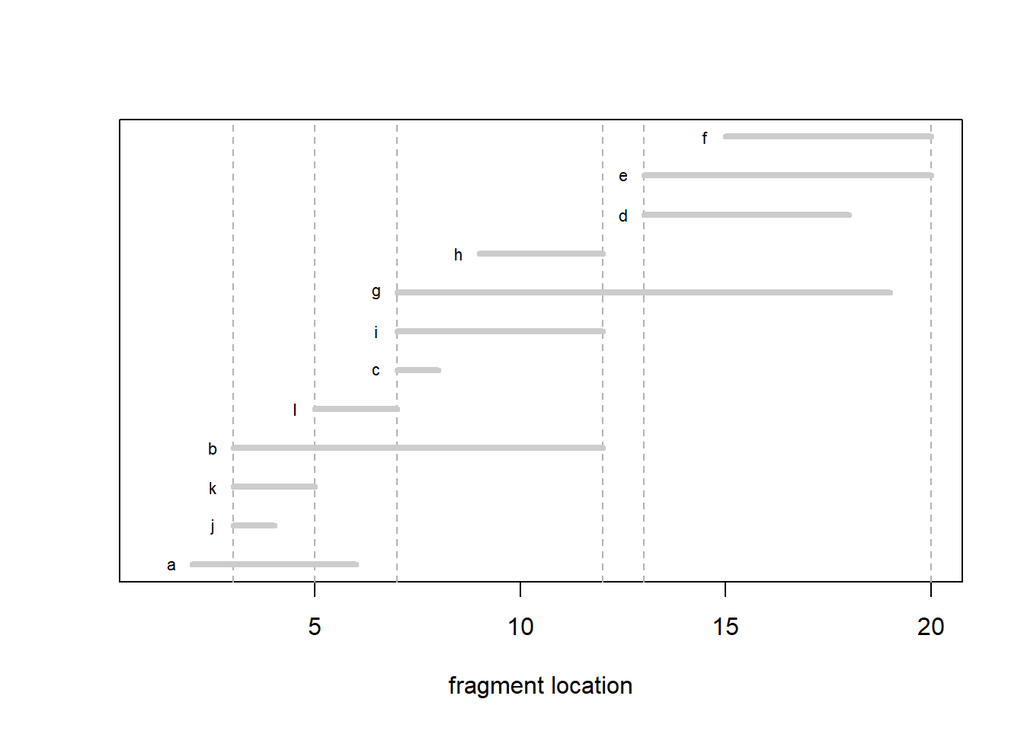

```r
frag1 <- cbind(beg=c(2,3,7,13,13,15,7,9,7, 3,3,5), end=c(6,12,8,18,20,20,19,12,12, 4,5,7))
rownames(frag1) <- letters[1:nrow(frag1)]
simpleFragFig(frag1)
```

Now we can make a matrix telling if some fragments do start or end at exactely the same position.

```r
countSameStartEnd(frag1)
```

```
##   beg end beg.n beg.rat end.n end.rat
## a   2   6    NA      NA    NA      NA
## b   3  12     3  0.2500     3  0.2500
## c   7   8     3  0.2500    NA      NA
## d  13  18     2  0.1667    NA      NA
## e  13  20     2  0.1667     2  0.1667
## f  15  20    NA      NA     2  0.1667
## g   7  19     3  0.2500    NA      NA
## h   9  12    NA      NA     3  0.2500
## i   7  12     3  0.2500     3  0.2500
## j   3   4     3  0.2500    NA      NA
## k   3   5     3  0.2500    NA      NA
## l   5   7    NA      NA    NA      NA
```

## Support for Graphical Output

### Convenient Paste-Collapse

The function `pasteC()` allows adding quotes and separating the last element by specific text (eg ‘and’).

```r
pasteC(1:4)
```

```
## [1] "1, 2, 3 and 4"
```

```r
pasteC(letters[1:4],quoteC="'")
```

```
## [1] "'a', 'b', 'c' and 'd'"
```

### Transform Numeric Values to Color-Gradient

By default most color-gradients end with a color very close to the beginning.

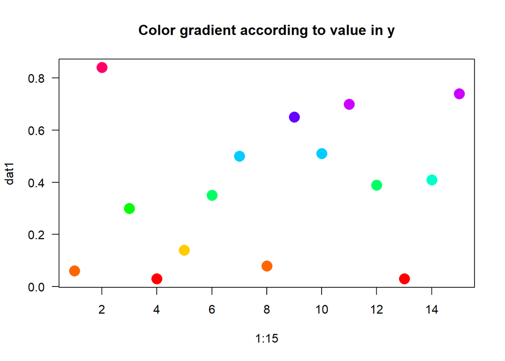

```r
set.seed(2015); dat1 <- round(runif(15),2)
plot(1:15, dat1, pch=16, cex=2, las=1, col=colorAccording2(dat1),
  main="Color gradient according to value in y")
```

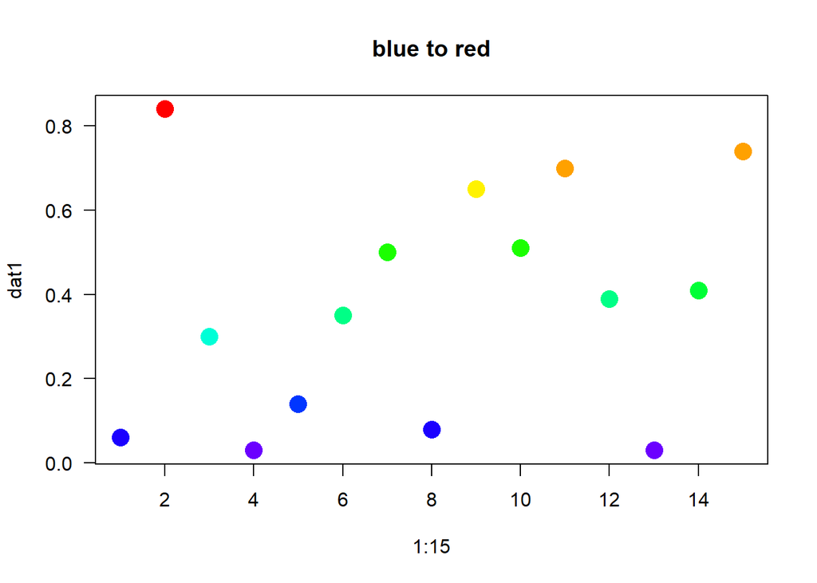

```r
# Here we modify the span of the color gradient
plot(1:15, dat1, pch=16, cex=2, las=1,
  col=colorAccording2(dat1, nStartO=0, nEndO=4, revCol=TRUE), main="blue to red")
```

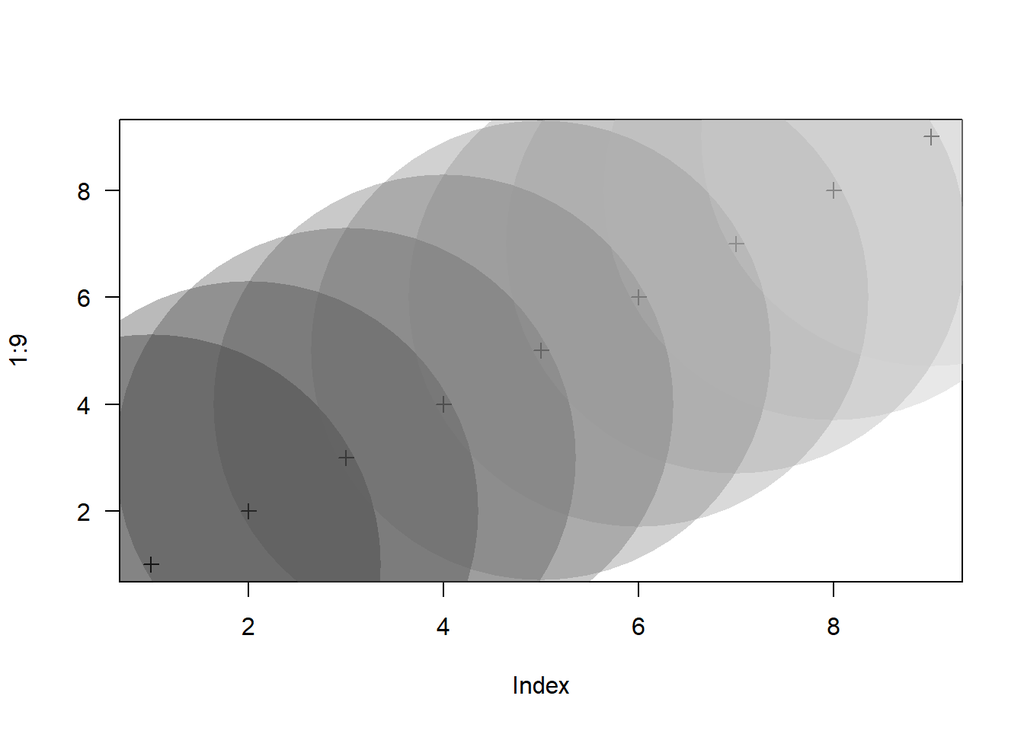

```r
# It is also possible to work with scales of transparency
plot(1:9, pch=3, las=1)
points(1:9, 1:9, col=transpGraySca(st=0, en=0.8, nSt=9,trans=0.3), cex=42, pch=16)
```

### Assign New Transparency To Given Colors

For this purpose you may use `convColorToTransp`.

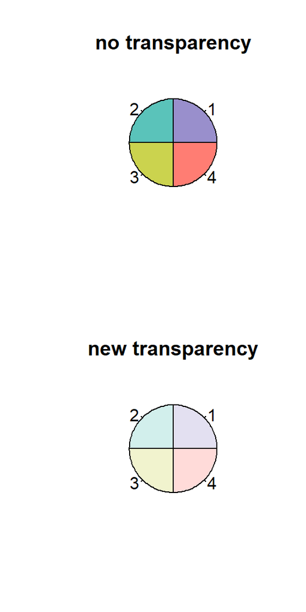

```r
col0 <- c("#998FCC","#5AC3BA","#CBD34E","#FF7D73")
col1 <- convColorToTransp(col0,alph=0.7)
layout(1:2)
pie(rep(1,length(col0)), col=col0, main="no transparency")
pie(rep(1,length(col1)), col=col1, main="new transparency")
```

### Print Matrix-Content As Plot

There are many ways of creating reports. If you want simply to combine a few plots into a pdf, the function `tableToPlot()` may be helpful to add a small table (eg overview of points/samples/files used in other plots of the same pdf). This function prints tables in the current graphical output/window (which may by a pdf-device).

## Other Convenience Functions

### Writing Compact Dates (more options …)

Many times it may be useful to add the date to filenames when saving data or plots as files. The built-in functions *date()*, *Sys.Date()* and *Sys.Time()* are a good way to start.

Generally I like to use abbreviated month-names since the order of writing the month is different in Europe compared to the USA, so this may help avoiding mis-interpreting dates insetad of writing the number of the Month. For example, 2021-03-05 means in Europe March 5th while in other places it means May 3rd.

The R-functions mentioned above use local language settings, so I wrote the function `sysDate` to produce compact versions of current the date, **independent to local language settings** (or not -if you prefer), ie locale-specific, (yes, in some languages - like French - the first 3 letters of the month may give ambiguous results !) and to avoid white space ’ ’ (which I prefer to avoid in file-names). Please look at the function’s help-page for all available options.

```r
## To get started
Sys.Date()
```

```
## [1] "2023-07-25"
```

```r
## Compact English names (in European order), no matter what your local settings are :
sysDate()
```

```
## [1] "25jul23"
```

The table below shows a number of options to write the date in English or using local month-names :

```r
tabD <- cbind(paste0("univ",1:6), c(sysDate(style="univ1"), sysDate(style="univ2"),
    sysDate(style="univ3"), sysDate(style="univ4"), as.character(sysDate(style="univ5")),
    sysDate(style="univ6")), paste0("   local",1:6),
  c(sysDate(style="local1"), sysDate(style="local2"), sysDate(style="local3"),
    sysDate(style="local4"), sysDate(style="local5"), sysDate(style="local6")))
knitr::kable(tabD, caption="Various ways of writing current date")
```

Various ways of writing current date

| univ1 | 25jul23 | local1 | 25jui23 |
| --- | --- | --- | --- |
| univ2 | 25Jul23 | local2 | 25Jui23 |
| univ3 | 25July2023 | local3 | 25Juil.2023 |
| univ4 | 25july2023 | local4 | 25juil.2023 |
| univ5 | 2023-07-25 | local5 | 25-juil.-2023 |
| univ6 | 2023-206 | local6 | 2023juil.25 |